# Aplicacion de la IA en el diseño de cruzamiento dirigidos. Variable madre

Gonzalo Rivera

2023-07-08

# 1. INTRODUCCIÓN

En este caso vamos a llevar a cabo los analisis para los modelos de clasificacion binaria, es decir, realizaremos los modelos siguiendo dos planteamiento, el primero seria ver si el modelo es capaz de diferenciar entre una madre y el resto

# 2. PREPROCESADO DE DATOS

Primero vamos a limpiar de NA.

```r
library(readxl)
datosm <- read_excel("C:/Users/gonza/Documents/TFM/data/datosred.xlsx")
```

```r
library(mice)
```

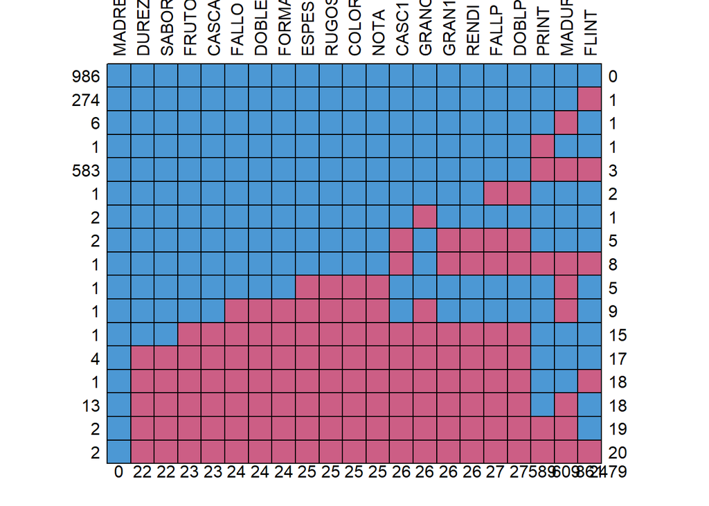

```
##     MADRE DUREZ SABOR FRUTO CASCA FALLO DOBLE FORMA ESPES RUGOS COLOR NOTA
## 986     1     1     1     1     1     1     1     1     1     1     1    1
## 274     1     1     1     1     1     1     1     1     1     1     1    1
## 6       1     1     1     1     1     1     1     1     1     1     1    1
## 1       1     1     1     1     1     1     1     1     1     1     1    1
## 583     1     1     1     1     1     1     1     1     1     1     1    1
## 1       1     1     1     1     1     1     1     1     1     1     1    1
## 2       1     1     1     1     1     1     1     1     1     1     1    1
## 2       1     1     1     1     1     1     1     1     1     1     1    1
## 1       1     1     1     1     1     1     1     1     1     1     1    1
## 1       1     1     1     1     1     1     1     1     0     0     0    0
## 1       1     1     1     1     1     0     0     0     0     0     0    0
## 1       1     1     1     0     0     0     0     0     0     0     0    0
## 4       1     0     0     0     0     0     0     0     0     0     0    0
## 1       1     0     0     0     0     0     0     0     0     0     0    0
```

[output cut: 23 more lines]

```r
library(forcats)
datam <- datosm[, c("MADRE", "FLINT", "PRINT", "MADUR", "FRUTO", "CASCA", "CASC1", "DUREZ", "GRANO", "GRAN1", "RENDI", "FALLO", "FALLP", "DOBLE", "DOBLP", "FORMA", "ESPES", "RUGOS", "COLOR", "SABOR", "NOTA")]
md.pattern(datam,rotate.names = T)
```

```r
library(dplyr)
datosmred <- datam[complete.cases(datam), ]
table(datosmred$MADRE)
```

```
##
##         A1353         A2146         A2198      Antoneta         C1126
##             3            17            17           102             7
##         C3091       D00i072       D00i078       D00i127       D00i203
##             2            55           117            24             6
##       D01i203       D01i466       D01i467       D01i560       D98i672
##            12             2            23             2             6
##       D98i694       D98i707 FerrxTuono283      Glorieta       Marcona
##            14             3             6             8            10
##         Marta     Masbovera         R1000         S2332         S4017
##            43            10           112            38            50
##         S5133
##           297
```

# 3. GENERACION DE MODELOS MULTIPLES PARA PADRE

Seleccionamos los padres con mas de 15 observaciones

```r
# Calcular el recuento de observaciones por cruce
recuentomadre <- table(datosmred$MADRE)

# Obtener los cruces con más de 15 observaciones
madressel <- names(recuentomadre)[recuentomadre > 15]

# Crear un nuevo conjunto de datos con los cruces seleccionados
datosmr <- datosmred[datosmred$MADRE %in% madressel, ]
```

```r
datosmr$MADRE <- as.factor(datosmr$MADRE)
table(datosmr$MADRE)
```

```
##
##    A2146    A2198 Antoneta  D00i072  D00i078  D00i127  D01i467    Marta
##       17       17      102       55      117       24       23       43
##    R1000    S2332    S4017    S5133
##      112       38       50      297
```

```r
str(datosmr)
```

```
## tibble [895 × 21] (S3: tbl_df/tbl/data.frame)
##  $ MADRE: Factor w/ 12 levels "A2146","A2198",..: 12 12 12 12 12 12 12 12 12 12 ...
##  $ FLINT: num [1:895] 3 3 3 3 2 2 3 3 3 2 ...
##  $ PRINT: num [1:895] 2 3 1 3 1 1 2 1 2 1 ...
##  $ MADUR: num [1:895] 221 235 224 208 208 214 211 208 214 207 ...
##  $ FRUTO: num [1:895] 25 25 25 25 25 25 25 20 25 25 ...
##  $ CASCA: num [1:895] 83 44 50 69 77 40 53 30 69 69 ...
##  $ CASC1: num [1:895] 3.32 1.76 2.12 2.76 3.11 ...
##  $ DUREZ: num [1:895] 5 2 2 4 4 2 3 2 4 4 ...
##  $ GRANO: num [1:895] 23 23 22 23 18 14 23 12 19 22 ...
##  $ GRAN1: num [1:895] 0.92 0.92 1 0.92 0.75 ...
##  $ RENDI: num [1:895] 27.7 52.3 47.2 33.3 24.1 ...
##  $ FALLO: num [1:895] 0 0 3 0 1 8 1 5 0 1 ...
##  $ FALLP: num [1:895] 0 0 12 0 4 32 4 25 0 4 ...
##  $ DOBLE: num [1:895] 0 1 0 14 0 0 0 0 0 3 ...
##  $ DOBLP: num [1:895] 0 4 0 56 0 0 0 0 0 12 ...
##  $ FORMA: num [1:895] 11 5 4 4 8 7 8 1 5 4 ...
##  $ ESPES: num [1:895] 2 3 2 2 2 1 2 2 3 2 ...
##  $ RUGOS: num [1:895] 1 1 2 2 2 1 3 2 2 2 ...
##  $ COLOR: num [1:895] 2 4 2 1 1 2 3 3 2 2 ...
##  $ SABOR: num [1:895] 3 3 3 2 3 3 3 3 3 3 ...
##  $ NOTA : num [1:895] 3 3 3 2 2 2 3 1 2 3 ...
```

Ahora visualizamos de forma grafica el numero de niveles por madre

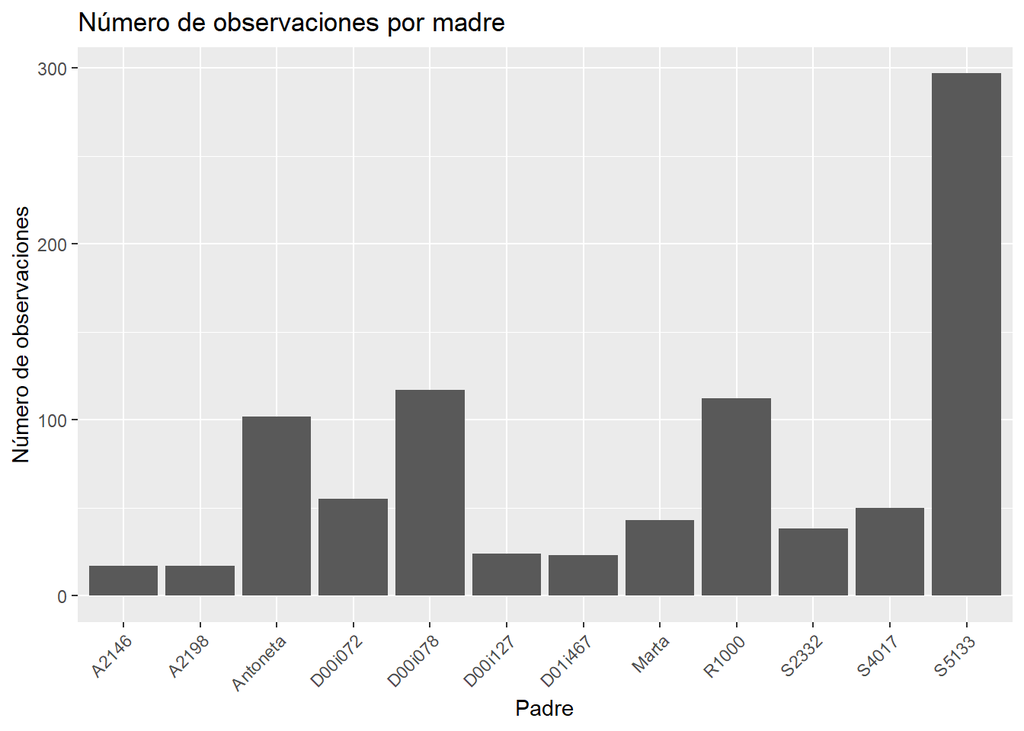

```r
library(ggplot2)
ggplot(datosmr, aes(x = MADRE)) +
  geom_bar() +
  labs(x = "Padre", y = "Número de observaciones", title = "Número de observaciones por madre") +
  theme(axis.text.x = element_text(angle = 45, hjust = 1))
```

## 3.1 SELECCION DE VARIABLES POR RANDOM FOREST

En este punto podemos llevar a cabo la seleccion de variables para luego comprobar los resultados.

```r
library(caret)
set.seed(12345)
datosmpart <- createDataPartition(datosmr$MADRE,p=0.8,list = FALSE)
datosm.train <- datosmr[datosmpart,]
datosm.test <- datosmr[-datosmpart,]
```

```r
subsets <- c(3:21) #Indicamos que cree subgrupos de entre 3 y 21 variables.

seeds <- vector(mode = "list", length = 6)

for(i in 1:10) seeds[[i]] <- sample.int(1000, length(subsets) + 1)
seeds[[11]] <- sample.int(1000, 1)

ctrl.treebag.rfe.cv.10 <- rfeControl(functions=rfFuncs ,
                                     method = "cv",
                                     number = 10,
                                     seeds = seeds,
                                     returnResamp="final",
                                     verbose = TRUE,
                                     allowParallel = TRUE)
```

```r
treebag.rfe.cv.10madre <- rfe(MADRE~., data=datosm.train,
                         sizes=subsets,
                         rfeControl=ctrl.treebag.rfe.cv.10)
```

Le quitamos el contenido de fit, para que no tenga tanto peso el archivo y guardammos el rds.

```r
treebag.rfe.cv.10madre$fit = NULL
saveRDS(treebag.rfe.cv.10madre, "C:/Users/gonza/Documents/TFM/treebag.fre.cv.10madre.rds")
```

```r
varselecmadre <- readRDS("C:/Users/gonza/Documents/TFM/treebag.fre.cv.10madre.rds")
varselecmadre$optVariables
```

```
##  [1] "MADUR" "GRAN1" "RENDI" "GRANO" "CASC1" "CASCA" "SABOR" "PRINT" "FORMA"
## [10] "NOTA"  "COLOR" "ESPES" "RUGOS" "DUREZ" "FLINT" "DOBLP" "DOBLE"
```

Nuestro modelo nos dice que las variables que mayor importancia tienen son: “MADUR” “GRAN1” “RENDI” “GRANO” “CASC1” “CASCA” “SABOR” “PRINT” “FORMA” “NOTA” “COLOR” “ESPES” “RUGOS” “DUREZ” “FLINT” “DOBLP” “DOBLE”

## 3.2 GENERACION DE MODELOS MULTIPLES CON DATOS SELECCION DE VARIABLES

```r
datosmsv <- datosmr[,c("MADRE", "MADUR" ,"GRAN1" ,"RENDI" ,"GRANO" ,"CASC1" ,"CASCA" ,"SABOR", "PRINT", "FORMA" ,"NOTA" , "COLOR" ,"ESPES" ,"RUGOS", "DUREZ", "FLINT" ,"DOBLP" ,"DOBLE")]
```

Primero balanceamos los datos

```r
# Crear una tabla con el recuento de los niveles de la variable "madre"
tablamadresv <- table(datosmsv$MADRE)

# Encontrar el nivel con el menor número de observaciones
minobsmsv <- min(tablamadresv)

# Crear una lista vacía para almacenar los datos balanceados
datosbmadresv <- data.frame()

# Iterar sobre cada nivel de la variable "madre"
for (nivel in levels(datosmsv$MADRE)) {
  # Subconjunto de datos para el nivel actual
  datosnivelmsv <- subset(datosmsv, MADRE == nivel)

  # Muestreo aleatorio de observaciones para igualar el número mínimo de observaciones
  datosmuestrmsv <- datosnivelmsv[sample(1:nrow(datosnivelmsv), minobsmsv), ]

  # Agregar los datos muestreados al conjunto de datos balanceados
  datosbmadresv <- rbind(datosbmadresv, datosmuestrmsv)
}

# Verificar el balance resultante
table(datosbmadresv$MADRE)
```

```
##
##    A2146    A2198 Antoneta  D00i072  D00i078  D00i127  D01i467    Marta
##       17       17       17       17       17       17       17       17
##    R1000    S2332    S4017    S5133
##       17       17       17       17
```

Creamos los datos de entrenamiento y de test.

```r
datosmsv.id <- createDataPartition(datosbmadresv$MADRE,p=0.8,list = FALSE)
datosmsv.tr <- datosbmadresv[datosmsv.id,]
datosmsv.te <- datosbmadresv[-datosmsv.id,]
datosmsv.tr_x <- datosmsv.tr
datosmsv.tr_x$MADRE=NULL

table(datosmsv.tr$MADRE)
```

```
##
##    A2146    A2198 Antoneta  D00i072  D00i078  D00i127  D01i467    Marta
##       14       14       14       14       14       14       14       14
##    R1000    S2332    S4017    S5133
##       14       14       14       14
```

### 3.2.1 Modelo ranger

```r
TrainCtrlRanger.3cv10 <- trainControl( # Crosvalidación de 10 pliegues con 3 repeticiones
  method = "repeatedcv",
  number = 10,
  repeats = 3,
  verboseIter=TRUE)
```

```r
modeloranger.3cv10.madresv <- train(x = datosmsv.tr_x,
                         y = datosmsv.tr$MADRE,
                         method = "ranger",  #En este caso el metodo ranger
                         trControl = TrainCtrlRanger.3cv10)
```

```r
saveRDS(modeloranger.3cv10.madresv, "modelorangermadresv.rds")
```

```r
modelorangermadresv <- readRDS("C:/Users/gonza/Documents/TFM/modelorangermadresv.rds")
modelorangermadresv
```

```
## Random Forest
##
## 168 samples
##  17 predictor
##  12 classes: 'A2146', 'A2198', 'Antoneta', 'D00i072', 'D00i078', 'D00i127', 'D01i467', 'Marta', 'R1000', 'S2332', 'S4017', 'S5133'
##
## No pre-processing
## Resampling: Cross-Validated (10 fold, repeated 3 times)
## Summary of sample sizes: 150, 152, 151, 152, 152, 150, ...
## Resampling results across tuning parameters:
##
##   mtry  splitrule   Accuracy   Kappa
##    2    gini        0.4208591  0.3655575
##    2    extratrees  0.4613923  0.4098009
##    9    gini        0.4125968  0.3574067
##    9    extratrees  0.4571799  0.4055589
##   17    gini        0.4173976  0.3628323
##   17    extratrees  0.4547686  0.4026773
##
## Tuning parameter 'min.node.size' was held constant at a value of 1
## Accuracy was used to select the optimal model using the largest value.
## The final values used for the model were mtry = 2, splitrule = extratrees
##  and min.node.size = 1.
```

```r
rangermsv.prediction <- predict(modelorangermadresv,datosmsv.te)
rangermsv.confimatrix <- confusionMatrix(rangermsv.prediction, datosmsv.te$MADRE)
rangermsv.confimatrix
```

### 3.2.2 Modelo random forest

```r
TrainCtrlRf.3cv10 <- trainControl( # Crosvalidación de 10 pliegues con 3 repeticiones
  method = "repeatedcv",
  number = 10,
  repeats = 3,
  verboseIter=TRUE)
```

```r
modelorf.3cv10.madresv <- train(x = datosmsv.tr_x,
                         y = datosmsv.tr$MADRE,
                         method = "rf",  #En este caso el metodo rf
                         trControl = TrainCtrlRf.3cv10)
```

```r
saveRDS(modelorf.3cv10.madresv, "modelorfmadresv.rds")
```

```r
modelorfmadresv <- readRDS("C:/Users/gonza/Documents/TFM/modelorfmadresv.rds")
modelorfmadresv
```

```
## Random Forest
##
## 168 samples
##  17 predictor
##  12 classes: 'A2146', 'A2198', 'Antoneta', 'D00i072', 'D00i078', 'D00i127', 'D01i467', 'Marta', 'R1000', 'S2332', 'S4017', 'S5133'
##
## No pre-processing
## Resampling: Cross-Validated (10 fold, repeated 3 times)
## Summary of sample sizes: 151, 155, 151, 150, 151, 152, ...
## Resampling results across tuning parameters:
##
##   mtry  Accuracy   Kappa
##    2    0.4222705  0.3667474
##    9    0.3862286  0.3285194
##   17    0.3847664  0.3269452
##
## Accuracy was used to select the optimal model using the largest value.
## The final value used for the model was mtry = 2.
```

```r
rfmsv.prediction <- predict(modelorfmadresv,datosmsv.te)
rfmsv.confimatrix <- confusionMatrix(rfmsv.prediction, datosmsv.te$MADRE)
rfmsv.confimatrix
```

### 3.2.3 Modelo SVM

```r
TrainCtrlSVM.3cv10 <- trainControl( # Crosvalidación de 10 pliegues con 3 repeticiones
  method = "repeatedcv",
  number = 10,
  repeats = 3,
  verboseIter=TRUE)
```

```r
modelorsvm.3cv10.madresv <- train(x = datosmsv.tr_x,
                         y = datosmsv.tr$MADRE,
                         method = "svmRadial",  #En este caso el metodo svmRadial
                         trControl = TrainCtrlSVM.3cv10)
```

```r
saveRDS(modelorsvm.3cv10.madresv, "modelosvmmadresv.rds")
```

```r
modelosvmmadresv <- readRDS("C:/Users/gonza/Documents/TFM/modelosvmmadresv.rds")
modelosvmmadresv
```

```
## Support Vector Machines with Radial Basis Function Kernel
##
## 168 samples
##  17 predictor
##  12 classes: 'A2146', 'A2198', 'Antoneta', 'D00i072', 'D00i078', 'D00i127', 'D01i467', 'Marta', 'R1000', 'S2332', 'S4017', 'S5133'
##
## No pre-processing
## Resampling: Cross-Validated (10 fold, repeated 3 times)
## Summary of sample sizes: 151, 152, 153, 149, 153, 151, ...
## Resampling results across tuning parameters:
##
##   C     Accuracy   Kappa
##   0.25  0.2220923  0.1716482
##   0.50  0.3543399  0.3006269
##   1.00  0.4203213  0.3672194
##
## Tuning parameter 'sigma' was held constant at a value of 0.03732784
## Accuracy was used to select the optimal model using the largest value.
## The final values used for the model were sigma = 0.03732784 and C = 1.
```

```r
library(kernlab)
svmmsv.prediction <- predict(modelosvmmadresv,datosmsv.te)
svmmsv.confimatrix <- confusionMatrix(svmmsv.prediction, datosmsv.te$MADRE)
svmmsv.confimatrix
```

Observamos que el enfoque multiclase no da lugar a buenos resultados.

## 3.3 GENERACION DE MODELOS MULTIPLES CON DATOS COMPLETOS, SIN SELECCION DE VARIABLES

Primero balanceamos los datos

```r
# Crear una tabla con el recuento de los niveles de la variable "familia"
tablamadreC <- table(datosmr$MADRE)

# Encontrar el nivel con el menor número de observaciones
minobsmC <- min(tablamadreC)

# Crear una lista vacía para almacenar los datos balanceados
datosbmadreC <- data.frame()

# Iterar sobre cada nivel de la variable "familia"
for (nivel in levels(datosmr$MADRE)) {
  # Subconjunto de datos para el nivel actual
  datosnivelmC <- subset(datosmr, MADRE == nivel)

  # Muestreo aleatorio de observaciones para igualar el número mínimo de observaciones
  datosmuestrmC <- datosnivelmC[sample(1:nrow(datosnivelmC), minobsmC), ]

  # Agregar los datos muestreados al conjunto de datos balanceados
  datosbmadreC <- rbind(datosbmadreC, datosmuestrmC)
}

# Verificar el balance resultante
table(datosbmadreC$MADRE)
```

```
##
##    A2146    A2198 Antoneta  D00i072  D00i078  D00i127  D01i467    Marta
##       17       17       17       17       17       17       17       17
##    R1000    S2332    S4017    S5133
##       17       17       17       17
```

Creamos los datos de entrenamiento y de test.

```r
datosmC.id <- createDataPartition(datosbmadreC$MADRE,p=0.8,list = FALSE)
datosmC.tr <- datosbmadreC[datosmC.id,]
datosmC.te <- datosbmadreC[-datosmC.id,]
datosmC.tr_x <- datosmC.tr
datosmC.tr_x$MADRE=NULL

table(datosmC.tr$MADRE)
```

```
##
##    A2146    A2198 Antoneta  D00i072  D00i078  D00i127  D01i467    Marta
##       14       14       14       14       14       14       14       14
##    R1000    S2332    S4017    S5133
##       14       14       14       14
```

### 5.3.1 Modelo ranger

```r
modeloranger.3cv10.madreC <- train(x = datosmC.tr_x,
                         y = datosmC.tr$MADRE,
                         method = "ranger",  #En este caso el metodo ranger
                         trControl = TrainCtrlRanger.3cv10)
```

```r
saveRDS(modeloranger.3cv10.madreC, "modelorangermadreC.rds")
```

```r
modelorangermadreC <- readRDS("C:/Users/gonza/Documents/TFM/modelorangermadreC.rds")
modelorangermadreC
```

```
## Random Forest
##
## 168 samples
##  20 predictor
##  12 classes: 'A2146', 'A2198', 'Antoneta', 'D00i072', 'D00i078', 'D00i127', 'D01i467', 'Marta', 'R1000', 'S2332', 'S4017', 'S5133'
##
## No pre-processing
## Resampling: Cross-Validated (10 fold, repeated 3 times)
## Summary of sample sizes: 152, 149, 151, 148, 154, 154, ...
## Resampling results across tuning parameters:
##
##   mtry  splitrule   Accuracy   Kappa
##    2    gini        0.4262854  0.3723787
##    2    extratrees  0.4519053  0.4006885
##   11    gini        0.4394572  0.3865141
##   11    extratrees  0.4663004  0.4157535
##   20    gini        0.4307528  0.3773386
##   20    extratrees  0.4896441  0.4417141
##
## Tuning parameter 'min.node.size' was held constant at a value of 1
## Accuracy was used to select the optimal model using the largest value.
## The final values used for the model were mtry = 20, splitrule = extratrees
##  and min.node.size = 1.
```

```r
rangermC.prediction <- predict(modelorangermadreC,datosmC.te)
rangermC.confimatrix <- confusionMatrix(rangermC.prediction, datosmC.te$MADRE)
rangermC.confimatrix
```

### 3.3.2 Modelo random forest

```r
modelorf.3cv10.madreC <- train(x = datosmC.tr_x,
                         y = datosmC.tr$MADRE,
                         method = "rf",  #En este caso el metodo rf
                         trControl = TrainCtrlRf.3cv10)
```

```r
saveRDS(modelorf.3cv10.madreC, "modelorfmadreC.rds")
```

```r
modelorfmadreC <- readRDS("C:/Users/gonza/Documents/TFM/modelorfmadreC.rds")
modelorfmadreC
```

```
## Random Forest
##
## 168 samples
##  20 predictor
##  12 classes: 'A2146', 'A2198', 'Antoneta', 'D00i072', 'D00i078', 'D00i127', 'D01i467', 'Marta', 'R1000', 'S2332', 'S4017', 'S5133'
##
## No pre-processing
## Resampling: Cross-Validated (10 fold, repeated 3 times)
## Summary of sample sizes: 149, 151, 153, 152, 151, 153, ...
## Resampling results across tuning parameters:
##
##   mtry  Accuracy   Kappa
##    2    0.4324958  0.3795884
##   11    0.4360115  0.3823681
##   20    0.4376955  0.3842106
##
## Accuracy was used to select the optimal model using the largest value.
## The final value used for the model was mtry = 20.
```

```r
rfmC.prediction <- predict(modelorfmadreC,datosmC.te)
rfmC.confimatrix <- confusionMatrix(rfmC.prediction, datosmC.te$MADRE)
rfmC.confimatrix
```

### 3.3.3 Modelo SVM

```r
modelorsvm.3cv10.madreC <- train(x = datosmC.tr_x,
                         y = datosmC.tr$MADRE,
                         method = "svmRadial",  #En este caso el metodo svmRadial
                         trControl = TrainCtrlSVM.3cv10)
```

```r
saveRDS(modelorsvm.3cv10.madreC, "modelosvmmadreC.rds")
```

```r
modelosvmmadreC <- readRDS("C:/Users/gonza/Documents/TFM/modelosvmmadreC.rds")
modelosvmmadreC
```

```
## Support Vector Machines with Radial Basis Function Kernel
##
## 168 samples
##  20 predictor
##  12 classes: 'A2146', 'A2198', 'Antoneta', 'D00i072', 'D00i078', 'D00i127', 'D01i467', 'Marta', 'R1000', 'S2332', 'S4017', 'S5133'
##
## No pre-processing
## Resampling: Cross-Validated (10 fold, repeated 3 times)
## Summary of sample sizes: 154, 151, 152, 152, 152, 151, ...
## Resampling results across tuning parameters:
##
##   C     Accuracy   Kappa
##   0.25  0.1818082  0.1296524
##   0.50  0.3136907  0.2572358
##   1.00  0.3908038  0.3339529
##
## Tuning parameter 'sigma' was held constant at a value of 0.04491406
## Accuracy was used to select the optimal model using the largest value.
## The final values used for the model were sigma = 0.04491406 and C = 1.
```

```r
svmmC.prediction <- predict(modelosvmmadreC,datosmC.te)
svmmC.confimatrix <- confusionMatrix(svmmC.prediction, datosmC.te$MADRE)
svmmC.confimatrix
```

## 3.4 COMPARACION DE MODELOS

```r
listamodelosmadres <- list(Rangervarselec=modelorangermadresv,RandomForestvarselec=modelorfmadresv,SupportVectorMachinevarselec=modelosvmmadresv,Rangervarcomp=modelorangermadreC, RandomForestvarcomp=modelorfmadreC, SupportVectorMachinevarcomp=modelosvmmadreC)
modelos.resamplem <- resamples(listamodelosmadres)
summary(modelos.resamplem)
```

```
##
## Call:
## summary.resamples(object = modelos.resamplem)
##
## Models: Rangervarselec, RandomForestvarselec, SupportVectorMachinevarselec, Rangervarcomp, RandomForestvarcomp, SupportVectorMachinevarcomp
## Number of resamples: 30
##
## Accuracy
##                                   Min.   1st Qu.    Median      Mean   3rd Qu.
## Rangervarselec               0.1764706 0.3946078 0.4721362 0.4613923 0.5607639
## RandomForestvarselec         0.1538462 0.3616071 0.4246324 0.4222705 0.5000000
## SupportVectorMachinevarselec 0.2105263 0.3333333 0.4105263 0.4203213 0.5000000
## Rangervarcomp                0.1764706 0.4210526 0.5000000 0.4896441 0.5770677
## RandomForestvarcomp          0.2222222 0.3684211 0.4330357 0.4376955 0.5000000
## SupportVectorMachinevarcomp  0.1176471 0.3529412 0.3819444 0.3908038 0.4444444
##                                   Max. NA's
## Rangervarselec               0.6428571    0
## RandomForestvarselec         0.6470588    0
## SupportVectorMachinevarselec 0.7058824    0
## Rangervarcomp                0.7857143    0
## RandomForestvarcomp          0.7500000    0
## SupportVectorMachinevarcomp  0.6470588    0
##
## Kappa
##                                    Min.   1st Qu.    Median      Mean   3rd Qu.
## Rangervarselec               0.09505703 0.3398281 0.4205931 0.4098009 0.5206243
## RandomForestvarselec         0.08333333 0.2944279 0.3676855 0.3667474 0.4554965
## SupportVectorMachinevarselec 0.13897281 0.2700115 0.3591540 0.3672194 0.4502277
## Rangervarcomp                0.10861423 0.3637703 0.4470990 0.4417141 0.5348514
## RandomForestvarcomp          0.15151515 0.3137408 0.3768060 0.3842106 0.4545455
## SupportVectorMachinevarcomp  0.03041825 0.2862286 0.3265575 0.3339529 0.3887893
##                                   Max. NA's
## Rangervarselec               0.6067416    0
## RandomForestvarselec         0.6106870    0
## SupportVectorMachinevarselec 0.6768061    0
## Rangervarcomp                0.7627119    0
## RandomForestvarcomp          0.7253219    0
## SupportVectorMachinevarcomp  0.6136364    0
```

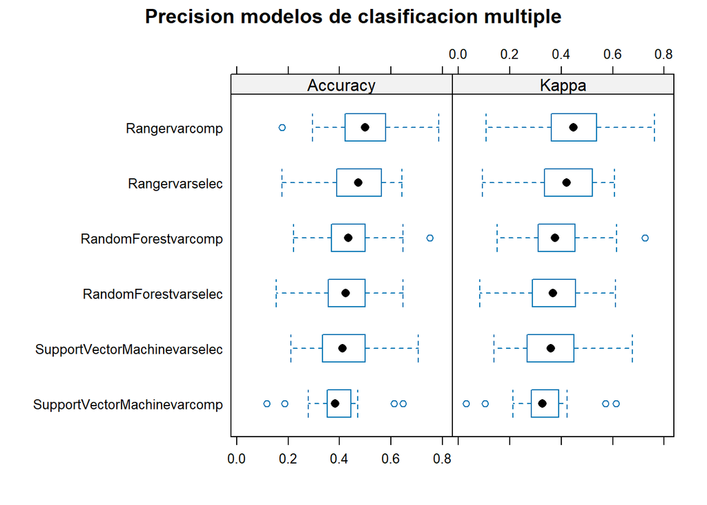

```r
bwplot(modelos.resamplem, main="Precision modelos de clasificacion multiple")
```

El modelo que obtiene unos mejores resultados en casos de clasificacion multiclase es el algoritmo Ranger, sin embargo, los valores de precision para los tres modelos son muy similares.

```r
difestm <- diff(modelos.resamplem, adjustment = "none")
summary(difestm)
```

```
##
## Call:
## summary.diff.resamples(object = difestm)
##
## Upper diagonal: estimates of the difference
## Lower diagonal: p-value for H0: difference = 0
##
## Accuracy
##                              Rangervarselec RandomForestvarselec
## Rangervarselec                               0.039122
## RandomForestvarselec         0.200672
## SupportVectorMachinevarselec 0.183056       0.957763
## Rangervarcomp                0.358052       0.049592
## RandomForestvarcomp          0.440946       0.637464
## SupportVectorMachinevarcomp  0.027762       0.295602
##                              SupportVectorMachinevarselec Rangervarcomp
## Rangervarselec                0.041071                    -0.028252
## RandomForestvarselec          0.001949                    -0.067374
## SupportVectorMachinevarselec                              -0.069323
## Rangervarcomp                0.055378
## RandomForestvarcomp          0.562357                     0.161909
## SupportVectorMachinevarcomp  0.300857                     0.000837
##                              RandomForestvarcomp SupportVectorMachinevarcomp
## Rangervarselec                0.023697            0.070588
## RandomForestvarselec         -0.015425            0.031467
## SupportVectorMachinevarselec -0.017374            0.029518
## Rangervarcomp                 0.051949            0.098840
## RandomForestvarcomp                               0.046892
## SupportVectorMachinevarcomp  0.101383
##
## Kappa
##                              Rangervarselec RandomForestvarselec
## Rangervarselec                               0.043054
## RandomForestvarselec         0.1972706
## SupportVectorMachinevarselec 0.2037220      0.9906151
## Rangervarcomp                0.3443022      0.0447250
## RandomForestvarcomp          0.4440423      0.6249965
## SupportVectorMachinevarcomp  0.0312747      0.3207074
##                              SupportVectorMachinevarselec Rangervarcomp
## Rangervarselec                0.042582                    -0.031913
## RandomForestvarselec         -0.000472                    -0.074967
## SupportVectorMachinevarselec                              -0.074495
## Rangervarcomp                0.0578029
## RandomForestvarcomp          0.6032047                    0.1551975
## SupportVectorMachinevarcomp  0.2803773                    0.0007274
##                              RandomForestvarcomp SupportVectorMachinevarcomp
## Rangervarselec                0.025590            0.075848
## RandomForestvarselec         -0.017463            0.032794
## SupportVectorMachinevarselec -0.016991            0.033266
## Rangervarcomp                 0.057503            0.107761
## RandomForestvarcomp                               0.050258
## SupportVectorMachinevarcomp  0.1107964
```

# 4. GENERACION DE MODELOS DE CLASIFICACIÓN BINARIA PARA PADRE

### 4.1.1 MODELOS CON DATOS SELECCION DE VARIABLES.

Primero llevamos a cabo la seleccion de variables

```r
datosm1sv <- datosmr
datosm1sv$MADRE <- fct_other(datosm1sv$MADRE, keep = "S5133", other_level = "OTROS")
table(datosm1sv$MADRE)
```

```
##
## S5133 OTROS
##   297   598
```

```r
set.seed(12345)
datosm1svpart <- createDataPartition(datosm1sv$MADRE,p=0.8,list = FALSE)
datosm1sv.train <- datosm1sv[datosm1svpart,]
datosm1sv.test <- datosm1sv[-datosm1svpart,]
```

Balanceamos los datos

```r
datosm1sv.train_x = datosm1sv.train

maskneg = which(datosm1sv.train_x$MADRE == "OTROS") #Seleccionamos las clases distintas
maskpos = which(datosm1sv.train_x$MADRE == "S5133") #Seleccinamos la clase
datosm1sv.train_x = datosm1sv.train_x[c(maskpos,sample(maskneg,length(maskpos))),]

datosm1sv.train_x = datosm1sv.train_x[sample(1:nrow(datosm1sv.train_x),nrow(datosm1sv.train_x)),]

datosm1sv.train_y = datosm1sv.train_x$MADRE

table(datosm1sv.train_x$MADRE)
```

```
##
## S5133 OTROS
##   238   238
```

```r
subsets <- c(3:21) #Indicamos que cree subgrupos de entre 3 y 21 variables.

seeds <- vector(mode = "list", length = 6)

for(i in 1:10) seeds[[i]] <- sample.int(1000, length(subsets) + 1)
seeds[[11]] <- sample.int(1000, 1)

ctrl.treebag.rfe.cv.10madrebin <- rfeControl(functions=rfFuncs ,
                                     method = "cv",
                                     number = 10,
                                     seeds = seeds,
                                     returnResamp="final",
                                     verbose = TRUE,
                                     allowParallel = TRUE)
```

```r
treebag.rfe.cv.10madrebin <- rfe(MADRE~., data=datosm1sv.train_x,
                         sizes=subsets,
                         rfeControl=ctrl.treebag.rfe.cv.10madrebin)
```

```r
treebag.rfe.cv.10madrebin$fit = NULL
saveRDS(treebag.rfe.cv.10madrebin, "C:/Users/gonza/Documents/TFM/treebag.fre.cv.10madrebin.rds")
```

```r
varselecmadrebin <- readRDS("C:/Users/gonza/Documents/TFM/treebag.fre.cv.10madrebin.rds")
varselecmadrebin$optVariables
```

```
##  [1] "RENDI" "PRINT" "NOTA"  "CASC1" "SABOR" "CASCA" "COLOR" "MADUR" "GRAN1"
## [10] "GRANO" "DUREZ"
```

Las variables seleccionadas son : “RENDI” “PRINT” “NOTA” “CASC1” “SABOR” “CASCA” “COLOR” “MADUR” “GRAN1” “GRANO” “DUREZ”.

Ahora llevaremos a cabo los modelos con estas variables para comprobar la precision

Primero volveremos a seleccionar de los datos reducidos las variables de interes

```r
datosm1 <- datosmr[, c("MADRE" ,"RENDI" ,"PRINT", "NOTA" , "CASC1" ,"SABOR", "CASCA" ,"COLOR" ,"MADUR" ,"GRAN1" ,"GRANO" ,"DUREZ")]
datosm1$MADRE <- fct_other(datosm1$MADRE, keep = "S5133", other_level = "OTROS")
table(datosm1$MADRE)
```

```
##
## S5133 OTROS
##   297   598
```

Balanceamos los datos.

```r
datosm1.id <- createDataPartition(datosm1$MADRE, p=0.7, list = FALSE)
datosm1.train <- datosm1[datosm1.id,]
datosm1.test <- datosm1[-datosm1.id,]
```

Ahora balancearemos los datos del train de cara a entrenar los modelos.

```r
datosm1.train_x = datosm1.train

maskneg = which(datosm1.train_x$MADRE == "OTROS") #Seleccionamos las clases distintas
maskpos = which(datosm1.train_x$MADRE == "S5133") #Seleccinamos la clase
datosm1.train_x = datosm1.train_x[c(maskpos,sample(maskneg,length(maskpos))),]

datosm1.train_x = datosm1.train_x[sample(1:nrow(datosm1.train_x),nrow(datosm1.train_x)),]

datosm1.train_y = datosm1.train_x$MADRE

table(datosm1.train_x$MADRE)
```

```
##
## S5133 OTROS
##   208   208
```

```r
datosm1.train_x$MADRE=NULL
```

Caret define por defecto la tecnica de remuestreo en la mitica bootstrap, sin embargo nosotros utilizaremos la crossvalidacion cruzada, en este caso de 10 pliegues con 3 repeticiones cada una (number=numero de pliegues -> 10 , repeats=numero de repeticiones -> 3). Además, añadimos la linea de comando verboseIter=TRUE para poder observar el avance del remuestreo en el entrenamiento del modelo.

```r
TrainCtrlRanger.3cv10 <- trainControl( # Crosvalidación de 10 pliegues con 3 repeticiones
  method = "repeatedcv",
  number = 10,
  repeats = 3,
  verboseIter=TRUE)
```

```r
modeloranger.3cv10.S5133madresv <- train(x = datosm1.train_x,
                         y = datosm1.train_y,
                         method = "ranger",  #En este caso el metodo ranger
                         trControl = TrainCtrlRanger.3cv10)
```

```r
saveRDS(modeloranger.3cv10.S5133madresv, "modelorangerS5133madresv.rds")
```

```r
modelorangerS5133madresv <- readRDS("C:/Users/gonza/Documents/TFM/modelorangerS5133madresv.rds")
modelorangerS5133madresv
```

```
## Random Forest
##
## 416 samples
##  11 predictor
##   2 classes: 'S5133', 'OTROS'
##
## No pre-processing
## Resampling: Cross-Validated (10 fold, repeated 3 times)
## Summary of sample sizes: 375, 374, 375, 374, 374, 374, ...
## Resampling results across tuning parameters:
##
##   mtry  splitrule   Accuracy   Kappa
##    2    gini        0.6625223  0.3251199
##    2    extratrees  0.6903765  0.3808414
##    6    gini        0.6577013  0.3155320
##    6    extratrees  0.6823606  0.3647781
##   11    gini        0.6672638  0.3346746
##   11    extratrees  0.6888482  0.3777446
##
## Tuning parameter 'min.node.size' was held constant at a value of 1
## Accuracy was used to select the optimal model using the largest value.
## The final values used for the model were mtry = 2, splitrule = extratrees
##  and min.node.size = 1.
```

```r
rangerm1sv.prediction <- predict(modelorangerS5133madresv,datosm1.test)
rangerm1sv.confimatrix <- confusionMatrix(rangerm1sv.prediction, datosm1.test$MADRE)
rangerm1sv.confimatrix
```

Ahora el modelo rf

```r
TrainCtrlRf.3cv10 <- trainControl( # Crosvalidación de 10 pliegues con 3 repeticiones
  method = "repeatedcv",
  number = 10,
  repeats = 3,
  verboseIter=TRUE)
```

```r
modelorf.3cv10.S5133madresv <- train(x = datosm1.train_x,
                         y = datosm1.train_y,
                         method = "rf",  #En este caso el metodo rf
                         trControl = TrainCtrlRf.3cv10)
saveRDS(modelorf.3cv10.S5133madresv, "modelorfS5133madresv.rds")
```

```r
modelorfS5133madresv <- readRDS("C:/Users/gonza/Documents/TFM/modelorfS5133madresv.rds")
modelorfS5133madresv
```

```
## Random Forest
##
## 416 samples
##  11 predictor
##   2 classes: 'S5133', 'OTROS'
##
## No pre-processing
## Resampling: Cross-Validated (10 fold, repeated 3 times)
## Summary of sample sizes: 375, 374, 374, 375, 374, 374, ...
## Resampling results across tuning parameters:
##
##   mtry  Accuracy   Kappa
##    2    0.6660859  0.3321586
##    6    0.6588657  0.3177578
##   11    0.6756678  0.3513782
##
## Accuracy was used to select the optimal model using the largest value.
## The final value used for the model was mtry = 11.
```

```r
rfm1sv.prediction <- predict(modelorfS5133madresv,datosm1.test)
rfm1sv.confimatrix <- confusionMatrix(rfm1sv.prediction, datosm1.test$MADRE)
rfm1sv.confimatrix
```

Ahora el algoritmo SVM

```r
TrainCtrlsvm.3cv10 <- trainControl( # Crosvalidación de 10 pliegues con 3 repeticiones
  method = "repeatedcv",
  number = 10,
  repeats = 3,
  verboseIter=TRUE)
```

```r
modelosvm.3cv10.S5133madresv <- train(x = datosm1.train_x,
                         y = datosm1.train_y,
                         method = "svmRadial",  #En este caso el metodo svm
                         trControl = TrainCtrlsvm.3cv10)
```

```r
saveRDS(modelosvm.3cv10.S5133madresv, "modelosvmS5133madresv.rds")
```

```r
modelosvmS5133madresv <- readRDS("C:/Users/gonza/Documents/TFM/modelosvmS5133madresv.rds")
modelosvmS5133madresv
```

```
## Support Vector Machines with Radial Basis Function Kernel
##
## 416 samples
##  11 predictor
##   2 classes: 'S5133', 'OTROS'
##
## No pre-processing
## Resampling: Cross-Validated (10 fold, repeated 3 times)
## Summary of sample sizes: 374, 374, 375, 375, 374, 375, ...
## Resampling results across tuning parameters:
##
##   C     Accuracy   Kappa
##   0.25  0.6460511  0.2916829
##   0.50  0.6643631  0.3282315
##   1.00  0.6802749  0.3601455
##
## Tuning parameter 'sigma' was held constant at a value of 0.08472155
## Accuracy was used to select the optimal model using the largest value.
## The final values used for the model were sigma = 0.08472155 and C = 1.
```

```r
svmm1sv.prediction <- predict(modelosvmS5133madresv,datosm1.test)
svmm1sv.confimatrix <- confusionMatrix(svmm1sv.prediction, datosm1.test$MADRE)
svmm1sv.confimatrix
```

### 4.1.2 MODELOS CON DATOS COMPLETOS

```r
datosm2 <- datosmr
datosm2$MADRE <- fct_other(datosm2$MADRE, keep = "S5133", other_level = "OTROS")
table(datosm2$MADRE)
```

```
##
## S5133 OTROS
##   297   598
```

Balanceamos los datos.

```r
datosm2.id <- createDataPartition(datosm2$MADRE, p=0.7, list = FALSE)
datosm2.train <- datosm2[datosm2.id,]
datosm2.test <- datosm2[-datosm2.id,]
```

Ahora balancearemos los datos del train de cara a entrenar los modelos.

```r
datosm2.train_x = datosm2.train

maskneg = which(datosm2.train_x$MADRE == "OTROS") #Seleccionamos las clases distintas
maskpos = which(datosm2.train_x$MADRE == "S5133") #Seleccinamos la clase
datosm2.train_x = datosm2.train_x[c(maskpos,sample(maskneg,length(maskpos))),]

datosm2.train_x = datosm2.train_x[sample(1:nrow(datosm2.train_x),nrow(datosm2.train_x)),]

datosm2.train_y = datosm2.train_x$MADRE

table(datosm2.train_x$MADRE)
```

```
##
## S5133 OTROS
##   208   208
```

```r
datosm2.train_x$MADRE=NULL
```

Caret define por defecto la tecnica de remuestreo en la mitica bootstrap, sin embargo nosotros utilizaremos la crossvalidacion cruzada, en este caso de 10 pliegues con 3 repeticiones cada una (number=numero de pliegues -> 10 , repeats=numero de repeticiones -> 3). Además, añadimos la linea de comando verboseIter=TRUE para poder observar el avance del remuestreo en el entrenamiento del modelo.

```r
modeloranger.3cv10.S5133madreC <- train(x = datosm2.train_x,
                         y = datosm2.train_y,
                         method = "ranger",  #En este caso el metodo ranger
                         trControl = TrainCtrlRanger.3cv10)
```

```r
saveRDS(modeloranger.3cv10.S5133madreC, "modelorangerS5133madreC.rds")
```

```r
modelorangerS5133madreC <- readRDS("C:/Users/gonza/Documents/TFM/modelorangerS5133madreC.rds")
modelorangerS5133madreC
```

```
## Random Forest
##
## 416 samples
##  20 predictor
##   2 classes: 'S5133', 'OTROS'
##
## No pre-processing
## Resampling: Cross-Validated (10 fold, repeated 3 times)
## Summary of sample sizes: 374, 375, 376, 374, 374, 375, ...
## Resampling results across tuning parameters:
##
##   mtry  splitrule   Accuracy   Kappa
##    2    gini        0.7020606  0.4041339
##    2    extratrees  0.7083914  0.4169082
##   11    gini        0.6939866  0.3879577
##   11    extratrees  0.7211653  0.4422278
##   20    gini        0.6971206  0.3943645
##   20    extratrees  0.7212234  0.4422835
##
## Tuning parameter 'min.node.size' was held constant at a value of 1
## Accuracy was used to select the optimal model using the largest value.
## The final values used for the model were mtry = 20, splitrule = extratrees
##  and min.node.size = 1.
```

```r
rangerm1C.prediction <- predict(modelorangerS5133madreC,datosm2.test)
rangerm1C.confimatrix <- confusionMatrix(rangerm1C.prediction, datosm2.test$MADRE)
rangerm1C.confimatrix
```

Ahora el modelo rf

```r
modelorf.3cv10.S5133madreC <- train(x = datosm2.train_x,
                         y = datosm2.train_y,
                         method = "rf",  #En este caso el metodo rf
                         trControl = TrainCtrlRf.3cv10)
```

```r
saveRDS(modelorf.3cv10.S5133madreC, "modelorfS5133madreC.rds")
```

```r
modelorfS5133madreC <- readRDS("C:/Users/gonza/Documents/TFM/modelorfS5133madreC.rds")
modelorfS5133madreC
```

```
## Random Forest
##
## 416 samples
##  20 predictor
##   2 classes: 'S5133', 'OTROS'
##
## No pre-processing
## Resampling: Cross-Validated (10 fold, repeated 3 times)
## Summary of sample sizes: 374, 374, 375, 374, 374, 374, ...
## Resampling results across tuning parameters:
##
##   mtry  Accuracy   Kappa
##    2    0.7137515  0.4277739
##   11    0.7169464  0.4341953
##   20    0.7050803  0.4104159
##
## Accuracy was used to select the optimal model using the largest value.
## The final value used for the model was mtry = 11.
```

```r
caret::varImp(modelorfS5133madreC)
```

```
## rf variable importance
##
##       Overall
## RENDI 100.000
## MADUR  79.770
## CASC1  65.257
## CASCA  58.191
## GRAN1  42.513
## NOTA   37.061
## GRANO  33.120
## PRINT  32.906
## FORMA  31.822
## COLOR  21.277
## FLINT  18.936
## ESPES  17.155
## SABOR  13.732
## RUGOS  13.221
## DUREZ  12.043
## DOBLP  10.517
## FALLP  10.490
## DOBLE   9.871
## FALLO   7.077
## FRUTO   0.000
```

```r
rfm1C.prediction <- predict(modelorfS5133madreC,datosm2.test)
rfm1C.confimatrix <- confusionMatrix(rfm1C.prediction, datosm2.test$MADRE)
rfm1C.confimatrix
```

Ahora el algoritmo SVM

```r
modelosvm.3cv10.S5133madreC <- train(x = datosm2.train_x,
                         y = datosm2.train_y,
                         method = "svmRadial",  #En este caso el metodo svm
                         trControl = TrainCtrlsvm.3cv10)
```

```r
saveRDS(modelosvm.3cv10.S5133madreC, "modelosvmS5133madreC.rds")
```

```r
modelosvmS5133madreC <- readRDS("C:/Users/gonza/Documents/TFM/modelosvmS5133madreC.rds")
modelosvmS5133madreC
```

```
## Support Vector Machines with Radial Basis Function Kernel
##
## 416 samples
##  20 predictor
##   2 classes: 'S5133', 'OTROS'
##
## No pre-processing
## Resampling: Cross-Validated (10 fold, repeated 3 times)
## Summary of sample sizes: 374, 374, 375, 375, 374, 374, ...
## Resampling results across tuning parameters:
##
##   C     Accuracy   Kappa
##   0.25  0.6794812  0.3592142
##   0.50  0.6914828  0.3831422
##   1.00  0.7059040  0.4122431
##
## Tuning parameter 'sigma' was held constant at a value of 0.04095186
## Accuracy was used to select the optimal model using the largest value.
## The final values used for the model were sigma = 0.04095186 and C = 1.
```

```r
svmm1C.prediction <- predict(modelosvmS5133madreC,datosm2.test)
svmm1C.confimatrix <- confusionMatrix(svmm1C.prediction, datosm2.test$MADRE)
svmm1C.confimatrix
```

### 4.1.3 COMPARACION DE MODELOS DE CLASIFICACION BINARIA

```r
listamodelosmadresS5133 <- list(Rangervarselec=modelorangerS5133madresv,RandomForestvarselec=modelorfS5133madresv,SupportVectorMachinevarselec=modelosvmS5133madresv,Rangervarcomp=modelorangerS5133madreC, RandomForestvarcomp=modelorfS5133madreC, SupportVectorMachinevarcomp=modelosvmS5133madreC)
modelos.resampleS5133 <- resamples(listamodelosmadresS5133)
summary(modelos.resampleS5133)
```

```
##
## Call:
## summary.resamples(object = modelos.resampleS5133)
##
## Models: Rangervarselec, RandomForestvarselec, SupportVectorMachinevarselec, Rangervarcomp, RandomForestvarcomp, SupportVectorMachinevarcomp
## Number of resamples: 30
##
## Accuracy
##                                   Min.   1st Qu.    Median      Mean   3rd Qu.
## Rangervarselec               0.5500000 0.6363240 0.6904762 0.6903765 0.7364983
## RandomForestvarselec         0.5365854 0.6428571 0.6904762 0.6756678 0.7142857
## SupportVectorMachinevarselec 0.5238095 0.6428571 0.6867015 0.6802749 0.7317073
## Rangervarcomp                0.5714286 0.6848142 0.7229965 0.7212234 0.7758420
## RandomForestvarcomp          0.5853659 0.6726190 0.7142857 0.7169464 0.7515970
## SupportVectorMachinevarcomp  0.5121951 0.6666667 0.7073171 0.7059040 0.7559524
##                                   Max. NA's
## Rangervarselec               0.8095238    0
## RandomForestvarselec         0.7857143    0
## SupportVectorMachinevarselec 0.8048780    0
## Rangervarcomp                0.8333333    0
## RandomForestvarcomp          0.8571429    0
## SupportVectorMachinevarcomp  0.8333333    0
##
## Kappa
##                                    Min.   1st Qu.    Median      Mean   3rd Qu.
## Rangervarselec               0.10000000 0.2716670 0.3809524 0.3808414 0.4737109
## RandomForestvarselec         0.06929510 0.2857143 0.3809524 0.3513782 0.4285714
## SupportVectorMachinevarselec 0.04761905 0.2857143 0.3735915 0.3601455 0.4611708
## Rangervarcomp                0.14285714 0.3676395 0.4455134 0.4422835 0.5526606
## RandomForestvarcomp          0.17122473 0.3452381 0.4285714 0.4341953 0.5029762
## SupportVectorMachinevarcomp  0.02843602 0.3333333 0.4121788 0.4122431 0.5119048
##                                   Max. NA's
## Rangervarselec               0.6190476    0
## RandomForestvarselec         0.5714286    0
## SupportVectorMachinevarselec 0.6104513    0
## Rangervarcomp                0.6666667    0
## RandomForestvarcomp          0.7142857    0
## SupportVectorMachinevarcomp  0.6666667    0
```

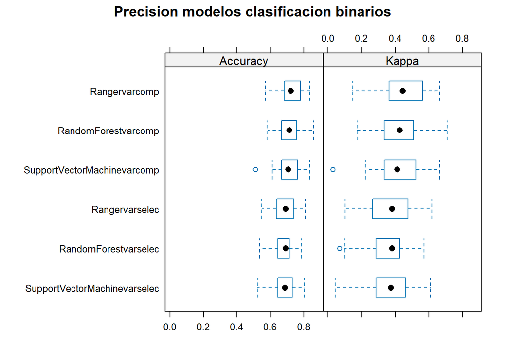

```r
bwplot(modelos.resampleS5133, main="Precision modelos clasificacion binarios")
```

```r
difestS5133 <- diff(modelos.resampleS5133, adjustment = "none")
summary(difestS5133)
```

```
##
## Call:
## summary.diff.resamples(object = difestS5133)
##
## Upper diagonal: estimates of the difference
## Lower diagonal: p-value for H0: difference = 0
##
## Accuracy
##                              Rangervarselec RandomForestvarselec
## Rangervarselec                               0.014709
## RandomForestvarselec         0.43746
## SupportVectorMachinevarselec 0.59664        0.79584
## Rangervarcomp                0.04560        0.02342
## RandomForestvarcomp          0.11436        0.01435
## SupportVectorMachinevarcomp  0.32724        0.10628
##                              SupportVectorMachinevarselec Rangervarcomp
## Rangervarselec                0.010102                    -0.030847
## RandomForestvarselec         -0.004607                    -0.045556
## SupportVectorMachinevarselec                              -0.040949
## Rangervarcomp                0.01520
## RandomForestvarcomp          0.01469                      0.79340
## SupportVectorMachinevarcomp  0.11298                      0.40161
##                              RandomForestvarcomp SupportVectorMachinevarcomp
## Rangervarselec               -0.026570           -0.015527
## RandomForestvarselec         -0.041279           -0.030236
## SupportVectorMachinevarselec -0.036672           -0.025629
## Rangervarcomp                 0.004277            0.015319
## RandomForestvarcomp                               0.011042
## SupportVectorMachinevarcomp  0.54363
##
## Kappa
##                              Rangervarselec RandomForestvarselec
## Rangervarselec                               0.029463
## RandomForestvarselec         0.43698
## SupportVectorMachinevarselec 0.58851        0.80664
## Rangervarcomp                0.04635        0.02400
## RandomForestvarcomp          0.11261        0.01401
## SupportVectorMachinevarcomp  0.31883        0.10267
##                              SupportVectorMachinevarselec Rangervarcomp
## Rangervarselec                0.020696                    -0.061442
## RandomForestvarselec         -0.008767                    -0.090905
## SupportVectorMachinevarselec                              -0.082138
## Rangervarcomp                0.01501
## RandomForestvarcomp          0.01373                      0.80428
## SupportVectorMachinevarcomp  0.10676                      0.40900
##                              RandomForestvarcomp SupportVectorMachinevarcomp
## Rangervarselec               -0.053354           -0.031402
## RandomForestvarselec         -0.082817           -0.060865
## SupportVectorMachinevarselec -0.074050           -0.052098
## Rangervarcomp                 0.008088            0.030040
## RandomForestvarcomp                               0.021952
## SupportVectorMachinevarcomp  0.54342
```

Sabiendo que el mejor enfoque consiste en utilizar todos las variables y generar los modelos con el algoritmo ranger, vamos a llevar a cabo la prediccion de la varible madre.

### 4.1.4 SELECCIÓN DEL MEJOR CRUZAMIENTO

```r
# Muestra inventada
muestra <- data.frame(FLINT = 5, PRINT = 5, MADUR = 200, FRUTO = 25, CASCA = 80, CASC1 = 2, DUREZ = 3, GRANO = 30, GRAN1 = 1,2 , RENDI = 100, FALLO = 0, FALLP = 0, DOBLE = 0, DOBLP = 0, FORMA = 4, ESPES = 3, RUGOS = 2, COLOR = 3, SABOR = 3, NOTA = 5)

# Predicción del grupo de la muestra inventada
prediccionoptimam <- predict(modelorangerS5133madreC, newdata = muestra)

# Resultado de la predicción
print(prediccionoptimam)
```

```
## [1] S5133
## Levels: S5133 OTROS
```

Nuestra almendro optimo podria pertenecer a dicha madre.

```r
# Muestra distinta
muestrados <- data.frame(FLINT = 3, PRINT = 3, MADUR = 220, FRUTO = 25, CASCA = 80, CASC1 = 2, DUREZ = 3, GRANO = 30, GRAN1 = 1,2 , RENDI = 80, FALLO = 0, FALLP = 0, DOBLE = 0, DOBLP = 0, FORMA = 4, ESPES = 3, RUGOS = 2, COLOR = 4, SABOR = 3, NOTA = 4)

# Predicción del grupo de la muestra optima
prediccionoptimados <- predict(modelorangerS5133madreC, newdata = muestrados)

# Resultado de la predicción
print(prediccionoptimados)
```

```
## [1] OTROS
## Levels: S5133 OTROS
```

A partir de ahora se llevara a cabo un enfoque de clasificacion binario sin seleccion de variables, utilizando el algoritmo ranger y se usara rf para ver la importancia de las variables.

## 4.2 GENERACION DE MODELOS DE CLASIFICACION BINARIA PARA CLASE POSITIVA R1000.

```r
datosm2 <- datosmr
datosm2$MADRE <- fct_other(datosm2$MADRE, keep = "R1000", other_level = "OTROS")
table(datosm2$MADRE)
```

```
##
## R1000 OTROS
##   112   783
```

Balanceamos los datos.

```r
datosm2.id <- createDataPartition(datosm2$MADRE, p=0.7, list = FALSE)
datosm2.train <- datosm2[datosm2.id,]
datosm2.test <- datosm2[-datosm2.id,]
```

Ahora balancearemos los datos del train de cara a entrenar los modelos.

```r
datosm2.train_x = datosm2.train

maskneg = which(datosm2.train_x$MADRE == "OTROS") #Seleccionamos las clases distintas
maskpos = which(datosm2.train_x$MADRE == "R1000") #Seleccinamos la clase
datosm2.train_x = datosm2.train_x[c(maskpos,sample(maskneg,length(maskpos))),]

datosm2.train_x = datosm2.train_x[sample(1:nrow(datosm2.train_x),nrow(datosm2.train_x)),]

datosm2.train_y = datosm2.train_x$MADRE

table(datosm2.train_x$MADRE)
```

```
##
## R1000 OTROS
##    79    79
```

```r
datosm2.train_x$MADRE=NULL
```

Caret define por defecto la tecnica de remuestreo en la mitica bootstrap, sin embargo nosotros utilizaremos la crossvalidacion cruzada, en este caso de 10 pliegues con 3 repeticiones cada una (number=numero de pliegues -> 10 , repeats=numero de repeticiones -> 3). Además, añadimos la linea de comando verboseIter=TRUE para poder observar el avance del remuestreo en el entrenamiento del modelo.

```r
modeloranger.3cv10.R1000m <- train(x = datosm2.train_x,
                         y = datosm2.train_y,
                         method = "ranger",  #En este caso el metodo ranger
                         trControl = TrainCtrlRanger.3cv10)
```

```r
saveRDS(modeloranger.3cv10.R1000m, "modelorangerR1000m.rds")
```

```r
modelorangerR1000m <- readRDS("C:/Users/gonza/Documents/TFM/modelorangerR1000m.rds")
modelorangerR1000m
```

```
## Random Forest
##
## 158 samples
##  20 predictor
##   2 classes: 'R1000', 'OTROS'
##
## No pre-processing
## Resampling: Cross-Validated (10 fold, repeated 3 times)
## Summary of sample sizes: 142, 142, 143, 142, 143, 142, ...
## Resampling results across tuning parameters:
##
##   mtry  splitrule   Accuracy   Kappa
##    2    gini        0.7592460  0.5186684
##    2    extratrees  0.7779762  0.5560020
##   11    gini        0.7529762  0.5059216
##   11    extratrees  0.7679762  0.5357897
##   20    gini        0.7317262  0.4636422
##   20    extratrees  0.7505952  0.5008484
##
## Tuning parameter 'min.node.size' was held constant at a value of 1
## Accuracy was used to select the optimal model using the largest value.
## The final values used for the model were mtry = 2, splitrule = extratrees
##  and min.node.size = 1.
```

```r
ranger.predictionm2 <- predict(modelorangerR1000m,datosm2.test)
ranger.confimatrixm2 <- confusionMatrix(ranger.predictionm2, datosm2.test$MADRE)
ranger.confimatrixm2
```

Ahora algorimto rf para la importancia

```r
modelorf.3cv10.R1000m <- train(x = datosm2.train_x,
                         y = datosm2.train_y,
                         method = "rf",  #En este caso el metodo rf
                         trControl = TrainCtrlRf.3cv10)
```

```r
saveRDS(modelorf.3cv10.R1000m, "modelorfR1000m.rds")
```

```r
modelorfR1000m <- readRDS("C:/Users/gonza/Documents/TFM/modelorfR1000m.rds")
modelorfR1000m
```

```
## Random Forest
##
## 158 samples
##  20 predictor
##   2 classes: 'R1000', 'OTROS'
##
## No pre-processing
## Resampling: Cross-Validated (10 fold, repeated 3 times)
## Summary of sample sizes: 142, 142, 143, 143, 142, 142, ...
## Resampling results across tuning parameters:
##
##   mtry  Accuracy   Kappa
##    2    0.7659722  0.5321685
##   11    0.7572222  0.5150218
##   20    0.7534722  0.5075617
##
## Accuracy was used to select the optimal model using the largest value.
## The final value used for the model was mtry = 2.
```

```r
caret::varImp(modelorfR1000m)
```

```
## rf variable importance
##
##       Overall
## GRAN1  100.00
## GRANO   88.61
## CASC1   78.50
## CASCA   75.65
## MADUR   65.17
## RENDI   63.93
## FORMA   56.40
## NOTA    43.22
## COLOR   38.56
## PRINT   35.51
## RUGOS   29.70
## FLINT   28.61
## DUREZ   19.85
## FALLO   19.68
## FALLP   17.95
## DOBLP   15.12
## SABOR   14.99
## ESPES   14.86
## DOBLE   14.27
## FRUTO    0.00
```

```r
rf.predictionm2 <- predict(modelorfR1000m,datosm2.test)
rf.confimatrixm2 <- confusionMatrix(rf.predictionm2, datosm2.test$MADRE)
rf.confimatrixm2
```

### 4.2.1 SELECCIÓN DEL MEJOR CRUZAMIENTO

```r
# Predicción del grupo de la muestra inventada
prediccionoptimam2 <- predict(modelorangerR1000m, newdata = muestra)

# Resultado de la predicción
print(prediccionoptimam2)
```

```
## [1] OTROS
## Levels: R1000 OTROS
```

Perteneceria a otro padre nuestra planta optima.

```r
# Predicción del grupo de la muestra inventada
prediccionoptimamdos2 <- predict(modelorangerR1000m, newdata = muestrados)

# Resultado de la predicción
print(prediccionoptimamdos2)
```

```
## [1] OTROS
## Levels: R1000 OTROS
```

## 4.3 GENERACION DE MODELOS DE CLASIFICACION BINARIA PARA CLASE POSITIVA D00-078

```r
datosm3 <- datosmr
datosm3$MADRE <- fct_other(datosm3$MADRE, keep = "D00i078", other_level = "OTROS")
table(datosm3$MADRE)
```

```
##
## D00i078   OTROS
##     117     778
```

Balanceamos los datos.

```r
datosm3.id <- createDataPartition(datosm3$MADRE, p=0.7, list = FALSE)
datosm3.train <- datosm3[datosm3.id,]
datosm3.test <- datosm3[-datosm3.id,]
```

Ahora balancearemos los datos del train de cara a entrenar los modelos.

```r
datosm3.train_x = datosm3.train

maskneg = which(datosm3.train_x$MADRE == "OTROS") #Seleccionamos las clases distintas
maskpos = which(datosm3.train_x$MADRE == "D00i078") #Seleccinamos la clase
datosm3.train_x = datosm3.train_x[c(maskpos,sample(maskneg,length(maskpos))),]

datosm3.train_x = datosm3.train_x[sample(1:nrow(datosm3.train_x),nrow(datosm3.train_x)),]

datosm3.train_y = datosm3.train_x$MADRE

table(datosm3.train_x$MADRE)
```

```
##
## D00i078   OTROS
##      82      82
```

```r
datosm3.train_x$MADRE=NULL
```

Caret define por defecto la tecnica de remuestreo en la mitica bootstrap, sin embargo nosotros utilizaremos la crossvalidacion cruzada, en este caso de 10 pliegues con 3 repeticiones cada una (number=numero de pliegues -> 10 , repeats=numero de repeticiones -> 3). Además, añadimos la linea de comando verboseIter=TRUE para poder observar el avance del remuestreo en el entrenamiento del modelo.

```r
modeloranger.3cv10.D00i078 <- train(x = datosm3.train_x,
                         y = datosm3.train_y,
                         method = "ranger",  #En este caso el metodo ranger
                         trControl = TrainCtrlRanger.3cv10)
```

```r
saveRDS(modeloranger.3cv10.D00i078, "modelorangerD00i078m.rds")
```

```r
modelorangerD00i078m <- readRDS("C:/Users/gonza/Documents/TFM/modelorangerD00i078m.rds")
modelorangerD00i078m
```

```
## Random Forest
##
## 164 samples
##  20 predictor
##   2 classes: 'D00i078', 'OTROS'
##
## No pre-processing
## Resampling: Cross-Validated (10 fold, repeated 3 times)
## Summary of sample sizes: 148, 148, 148, 148, 148, 148, ...
## Resampling results across tuning parameters:
##
##   mtry  splitrule   Accuracy   Kappa
##    2    gini        0.7666258  0.5331714
##    2    extratrees  0.7535948  0.5070860
##   11    gini        0.7630310  0.5257983
##   11    extratrees  0.7691993  0.5377075
##   20    gini        0.7632625  0.5252722
##   20    extratrees  0.7832925  0.5657394
##
## Tuning parameter 'min.node.size' was held constant at a value of 1
## Accuracy was used to select the optimal model using the largest value.
## The final values used for the model were mtry = 20, splitrule = extratrees
##  and min.node.size = 1.
```

```r
ranger.predictionm3 <- predict(modelorangerD00i078m,datosm3.test)
ranger.confimatrixm3 <- confusionMatrix(ranger.predictionm3, datosm3.test$MADRE)
ranger.confimatrixm3
```

Ahora algorimto rf para la importancia

```r
modelorf.3cv10.D00i078 <- train(x = datosm3.train_x,
                         y = datosm3.train_y,
                         method = "rf",  #En este caso el metodo rf
                         trControl = TrainCtrlRf.3cv10)
```

```r
saveRDS(modelorf.3cv10.D00i078, "modelorfD00i078m.rds")
```

```r
modelorfD00i078m <- readRDS("C:/Users/gonza/Documents/TFM/modelorfD00i078m.rds")
modelorfD00i078m
```

```
## Random Forest
##
## 164 samples
##  20 predictor
##   2 classes: 'D00i078', 'OTROS'
##
## No pre-processing
## Resampling: Cross-Validated (10 fold, repeated 3 times)
## Summary of sample sizes: 148, 148, 148, 148, 148, 147, ...
## Resampling results across tuning parameters:
##
##   mtry  Accuracy   Kappa
##    2    0.7690632  0.5390559
##   11    0.7537854  0.5083579
##   20    0.7533088  0.5072826
##
## Accuracy was used to select the optimal model using the largest value.
## The final value used for the model was mtry = 2.
```

```r
caret::varImp(modelorfD00i078m)
```

```
## rf variable importance
##
##       Overall
## MADUR 100.000
## RENDI  90.955
## CASC1  71.838
## CASCA  71.301
## GRAN1  67.443
## FORMA  58.702
## GRANO  58.254
## FLINT  48.282
## PRINT  42.667
## COLOR  39.915
## RUGOS  36.431
## NOTA   34.315
## ESPES  24.977
## FALLP  22.494
## DOBLE  20.568
## DOBLP  19.872
## FALLO  19.160
## DUREZ  12.762
## SABOR   5.115
## FRUTO   0.000
```

```r
rf.predictionm3 <- predict(modelorfD00i078m,datosm3.test)
rf.confimatrixm3 <- confusionMatrix(rf.predictionm3, datosm3.test$MADRE)
rf.confimatrixm3
```

### 4.3.1 SELECCIÓN DEL MEJOR CRUZAMIENTO

```r
# Predicción del grupo de la muestra inventada
prediccionoptimam3 <- predict(modelorangerD00i078m, newdata = muestra)

# Resultado de la predicción
print(prediccionoptimam3)
```

```
## [1] OTROS
## Levels: D00i078 OTROS
```

Perteneceria a otro padre nuestra planta optima.

```r
# Predicción del grupo de la muestra inventada
prediccionoptimamdos3 <- predict(modelorangerD00i078m, newdata = muestrados)

# Resultado de la predicción
print(prediccionoptimamdos3)
```

```
## [1] OTROS
## Levels: D00i078 OTROS
```

## 4.4 GENERACION DE MODELOS DE CLASIFICACION BINARIA PARA CLASE POSITIVA Antoñeta

```r
datosm4 <- datosmr
datosm4$MADRE <- fct_other(datosm4$MADRE, keep = "Antoneta", other_level = "OTROS")
table(datosm4$MADRE)
```

```
##
## Antoneta    OTROS
##      102      793
```

Balanceamos los datos.

```r
datosm4.id <- createDataPartition(datosm4$MADRE, p=0.7, list = FALSE)
datosm4.train <- datosm4[datosm4.id,]
datosm4.test <- datosm4[-datosm4.id,]
```

Ahora balancearemos los datos del train de cara a entrenar los modelos.

```r
datosm4.train_x = datosm4.train

maskneg = which(datosm4.train_x$MADRE == "OTROS") #Seleccionamos las clases distintas
maskpos = which(datosm4.train_x$MADRE == "Antoneta") #Seleccinamos la clase
datosm4.train_x = datosm4.train_x[c(maskpos,sample(maskneg,length(maskpos))),]

datosm4.train_x = datosm4.train_x[sample(1:nrow(datosm4.train_x),nrow(datosm4.train_x)),]

datosm4.train_y = datosm4.train_x$MADRE

table(datosm4.train_x$MADRE)
```

```
##
## Antoneta    OTROS
##       72       72
```

```r
datosm4.train_x$MADRE=NULL
```

Caret define por defecto la tecnica de remuestreo en la mitica bootstrap, sin embargo nosotros utilizaremos la crossvalidacion cruzada, en este caso de 10 pliegues con 3 repeticiones cada una (number=numero de pliegues -> 10 , repeats=numero de repeticiones -> 3). Además, añadimos la linea de comando verboseIter=TRUE para poder observar el avance del remuestreo en el entrenamiento del modelo.

```r
modeloranger.3cv10.Antonetam <- train(x = datosm4.train_x,
                         y = datosm4.train_y,
                         method = "ranger",  #En este caso el metodo ranger
                         trControl = TrainCtrlRanger.3cv10)
```

```r
saveRDS(modeloranger.3cv10.Antonetam, "modelorangerAntonetam.rds")
```

```r
modelorangerAntonetam <- readRDS("C:/Users/gonza/Documents/TFM/modelorangerAntonetam.rds")
modelorangerAntonetam
```

```
## Random Forest
##
## 144 samples
##  20 predictor
##   2 classes: 'Antoneta', 'OTROS'
##
## No pre-processing
## Resampling: Cross-Validated (10 fold, repeated 3 times)
## Summary of sample sizes: 129, 130, 130, 130, 129, 130, ...
## Resampling results across tuning parameters:
##
##   mtry  splitrule   Accuracy   Kappa
##    2    gini        0.8023413  0.6042964
##    2    extratrees  0.7774008  0.5549863
##   11    gini        0.8213889  0.6424071
##   11    extratrees  0.7915476  0.5829138
##   20    gini        0.8118651  0.6228804
##   20    extratrees  0.7980556  0.5954763
##
## Tuning parameter 'min.node.size' was held constant at a value of 1
## Accuracy was used to select the optimal model using the largest value.
## The final values used for the model were mtry = 11, splitrule = gini
##  and min.node.size = 1.
```

```r
ranger.predictionm4 <- predict(modelorangerAntonetam,datosm4.test)
ranger.confimatrixm4 <- confusionMatrix(ranger.predictionm4, datosm4.test$MADRE)
ranger.confimatrixm4
```

Ahora algorimto rf para la importancia

```r
modelorf.3cv10.Antonetam <- train(x = datosm4.train_x,
                         y = datosm4.train_y,
                         method = "rf",  #En este caso el metodo rf
                         trControl = TrainCtrlRf.3cv10)
```

```r
saveRDS(modelorf.3cv10.Antonetam, "modelorfAntonetam.rds")
```

```r
modelorfAntonetam <- readRDS("C:/Users/gonza/Documents/TFM/modelorfAntonetam.rds")
modelorfAntonetam
```

```
## Random Forest
##
## 144 samples
##  20 predictor
##   2 classes: 'Antoneta', 'OTROS'
##
## No pre-processing
## Resampling: Cross-Validated (10 fold, repeated 3 times)
## Summary of sample sizes: 130, 129, 129, 129, 130, 130, ...
## Resampling results across tuning parameters:
##
##   mtry  Accuracy   Kappa
##    2    0.7961508  0.5925600
##   11    0.7986706  0.5982363
##   20    0.7820040  0.5645932
##
## Accuracy was used to select the optimal model using the largest value.
## The final value used for the model was mtry = 11.
```

```r
caret::varImp(modelorfAntonetam)
```

```
## rf variable importance
##
##       Overall
## MADUR 100.000
## GRANO  58.519
## GRAN1  52.710
## CASCA  19.564
## NOTA   17.867
## FLINT  17.701
## CASC1  16.387
## RENDI  16.091
## FORMA  14.759
## RUGOS   9.266
## COLOR   7.574
## SABOR   7.440
## PRINT   6.876
## ESPES   5.914
## DUREZ   5.907
## DOBLE   5.339
## FALLP   4.954
## FALLO   4.830
## DOBLP   4.611
## FRUTO   0.000
```

```r
rf.predictionm4 <- predict(modelorfAntonetam,datosm4.test)
rf.confimatrixm4 <- confusionMatrix(rf.predictionm4, datosm4.test$MADRE)
rf.confimatrixm4
```

### 4.4.1 SELECCIÓN DEL MEJOR CRUZAMIENTO

```r
# Predicción del grupo de la muestra inventada
prediccionoptimam4 <- predict(modelorangerAntonetam, newdata = muestra)

# Resultado de la predicción
print(prediccionoptimam4)
```

```
## [1] Antoneta
## Levels: Antoneta OTROS
```

Perteneceria a Antoneta nuestra planta optima.

```r
# Predicción del grupo de la muestra inventada
prediccionoptimamdos4 <- predict(modelorangerAntonetam, newdata = muestrados)

# Resultado de la predicción
print(prediccionoptimamdos4)
```

```
## [1] OTROS
## Levels: Antoneta OTROS
```

## 4.5 GENERACION DE MODELOS DE CLASIFICACION BINARIA PARA CLASE POSITIVA D00-072

```r
datosm5 <- datosmr
datosm5$MADRE <- fct_other(datosm5$MADRE, keep = "D00i072", other_level = "OTROS")
table(datosm5$MADRE)
```

```
##
## D00i072   OTROS
##      55     840
```

Balanceamos los datos.

```r
datosm5.id <- createDataPartition(datosm5$MADRE, p=0.7, list = FALSE)
datosm5.train <- datosm5[datosm5.id,]
datosm5.test <- datosm5[-datosm5.id,]
```

Ahora balancearemos los datos del train de cara a entrenar los modelos.

```r
datosm5.train_x = datosm5.train

maskneg = which(datosm5.train_x$MADRE == "OTROS") #Seleccionamos las clases distintas
maskpos = which(datosm5.train_x$MADRE == "D00i072") #Seleccinamos la clase
datosm5.train_x = datosm5.train_x[c(maskpos,sample(maskneg,length(maskpos))),]

datosm5.train_x = datosm5.train_x[sample(1:nrow(datosm5.train_x),nrow(datosm5.train_x)),]

datosm5.train_y = datosm5.train_x$MADRE

table(datosm5.train_x$MADRE)
```

```
##
## D00i072   OTROS
##      39      39
```

```r
datosm5.train_x$MADRE=NULL
```

Caret define por defecto la tecnica de remuestreo en la mitica bootstrap, sin embargo nosotros utilizaremos la crossvalidacion cruzada, en este caso de 10 pliegues con 3 repeticiones cada una (number=numero de pliegues -> 10 , repeats=numero de repeticiones -> 3). Además, añadimos la linea de comando verboseIter=TRUE para poder observar el avance del remuestreo en el entrenamiento del modelo.

```r
modeloranger.3cv10.D00i072 <- train(x = datosm5.train_x,
                         y = datosm5.train_y,
                         method = "ranger",  #En este caso el metodo ranger
                         trControl = TrainCtrlRanger.3cv10)
```

```r
saveRDS(modeloranger.3cv10.D00i072, "modelorangerD00i072m.rds")
```

```r
modelorangerD00i072m <- readRDS("C:/Users/gonza/Documents/TFM/modelorangerD00i072m.rds")
modelorangerD00i072m
```

```
## Random Forest
##
## 78 samples
## 20 predictors
##  2 classes: 'D00i072', 'OTROS'
##
## No pre-processing
## Resampling: Cross-Validated (10 fold, repeated 3 times)
## Summary of sample sizes: 70, 71, 70, 70, 70, 71, ...
## Resampling results across tuning parameters:
##
##   mtry  splitrule   Accuracy   Kappa
##    2    gini        0.6964286  0.3879859
##    2    extratrees  0.7654762  0.5331514
##   11    gini        0.7053571  0.4072082
##   11    extratrees  0.7690476  0.5367614
##   20    gini        0.7196429  0.4375493
##   20    extratrees  0.7869048  0.5744619
##
## Tuning parameter 'min.node.size' was held constant at a value of 1
## Accuracy was used to select the optimal model using the largest value.
## The final values used for the model were mtry = 20, splitrule = extratrees
##  and min.node.size = 1.
```

```r
ranger.predictionm5 <- predict(modelorangerD00i072m,datosm5.test)
ranger.confimatrixm5 <- confusionMatrix(ranger.predictionm5, datosm5.test$MADRE)
ranger.confimatrixm5
```

Ahora algorimto rf para la importancia

```r
modelorf.3cv10.D00i072 <- train(x = datosm5.train_x,
                         y = datosm5.train_y,
                         method = "rf",  #En este caso el metodo rf
                         trControl = TrainCtrlRf.3cv10)
```

```r
saveRDS(modelorf.3cv10.D00i072, "modelorfD00i072m.rds")
```

```r
modelorfD00i072m <- readRDS("C:/Users/gonza/Documents/TFM/modelorfD00i072m.rds")
modelorfD00i072m
```

```
## Random Forest
##
## 78 samples
## 20 predictors
##  2 classes: 'D00i072', 'OTROS'
##
## No pre-processing
## Resampling: Cross-Validated (10 fold, repeated 3 times)
## Summary of sample sizes: 70, 70, 70, 70, 71, 70, ...
## Resampling results across tuning parameters:
##
##   mtry  Accuracy   Kappa
##    2    0.6549603  0.3113846
##   11    0.6474206  0.2934444
##   20    0.6634921  0.3247711
##
## Accuracy was used to select the optimal model using the largest value.
## The final value used for the model was mtry = 20.
```

```r
caret::varImp(modelorfD00i072m)
```

```
## rf variable importance
##
##        Overall
## MADUR 100.0000
## COLOR  89.1946
## RUGOS  76.7416
## FORMA  67.3559
## RENDI  61.7754
## CASCA  59.7063
## GRAN1  54.1635
## CASC1  43.3864
## FLINT  24.7238
## NOTA   24.3769
## ESPES  23.1678
## GRANO  22.5085
## PRINT  15.9865
## DUREZ  14.3036
## DOBLP  12.1717
## DOBLE  11.5260
## FALLP   7.0303
## FALLO   6.6757
## SABOR   0.7403
## FRUTO   0.0000
```

```r
rf.predictionm5 <- predict(modelorfD00i072m,datosm5.test)
rf.confimatrixm5 <- confusionMatrix(rf.predictionm5, datosm5.test$MADRE)
rf.confimatrixm5
```

### 4.5.1 SELECCIÓN DEL MEJOR CRUZAMIENTO

```r
# Predicción del grupo de la muestra inventada
prediccionoptimam5 <- predict(modelorangerD00i072m, newdata = muestra)

# Resultado de la predicción
print(prediccionoptimam5)
```

```
## [1] OTROS
## Levels: D00i072 OTROS
```

Perteneceria a otra madre nuestra planta optima.

```r
# Predicción del grupo de la muestra inventada
prediccionoptimamdos5 <- predict(modelorangerD00i072m, newdata = muestrados)

# Resultado de la predicción
print(prediccionoptimamdos5)
```

```
## [1] OTROS
## Levels: D00i072 OTROS
```

## 4.6 GENERACION DE MODELOS DE CLASIFICACION BINARIA PARA CLASE POSITIVA S4017

```r
datosm6 <- datosmr
datosm6$MADRE <- fct_other(datosm6$MADRE, keep = "S4017", other_level = "OTROS")
table(datosm6$MADRE)
```

```
##
## S4017 OTROS
##    50   845
```

Balanceamos los datos.

```r
datosm6.id <- createDataPartition(datosm6$MADRE, p=0.7, list = FALSE)
datosm6.train <- datosm6[datosm6.id,]
datosm6.test <- datosm6[-datosm6.id,]
```

Ahora balancearemos los datos del train de cara a entrenar los modelos.

```r
datosm6.train_x = datosm6.train

maskneg = which(datosm6.train_x$MADRE == "OTROS") #Seleccionamos las clases distintas
maskpos = which(datosm6.train_x$MADRE == "S4017") #Seleccinamos la clase
datosm6.train_x = datosm6.train_x[c(maskpos,sample(maskneg,length(maskpos))),]

datosm6.train_x = datosm6.train_x[sample(1:nrow(datosm6.train_x),nrow(datosm6.train_x)),]

datosm6.train_y = datosm6.train_x$MADRE

table(datosm6.train_x$MADRE)
```

```
##
## S4017 OTROS
##    35    35
```

```r
datosm6.train_x$MADRE=NULL
```

Caret define por defecto la tecnica de remuestreo en la mitica bootstrap, sin embargo nosotros utilizaremos la crossvalidacion cruzada, en este caso de 10 pliegues con 3 repeticiones cada una (number=numero de pliegues -> 10 , repeats=numero de repeticiones -> 3). Además, añadimos la linea de comando verboseIter=TRUE para poder observar el avance del remuestreo en el entrenamiento del modelo.

```r
modeloranger.3cv10.S4017m <- train(x = datosm6.train_x,
                         y = datosm6.train_y,
                         method = "ranger",  #En este caso el metodo ranger
                         trControl = TrainCtrlRanger.3cv10)
```

```r
saveRDS(modeloranger.3cv10.S4017m, "modelorangerS4017m.rds")
```

```r
modelorangerS4017m <- readRDS("C:/Users/gonza/Documents/TFM/modelorangerS4017m.rds")
modelorangerS4017m
```

```
## Random Forest
##
## 70 samples
## 20 predictors
##  2 classes: 'S4017', 'OTROS'
##
## No pre-processing
## Resampling: Cross-Validated (10 fold, repeated 3 times)
## Summary of sample sizes: 63, 63, 62, 64, 64, 62, ...
## Resampling results across tuning parameters:
##
##   mtry  splitrule   Accuracy   Kappa
##    2    gini        0.8406746  0.6673574
##    2    extratrees  0.8390873  0.6695431
##   11    gini        0.8545635  0.7073958
##   11    extratrees  0.8494048  0.6892696
##   20    gini        0.8414683  0.6820002
##   20    extratrees  0.8589286  0.7117140
##
## Tuning parameter 'min.node.size' was held constant at a value of 1
## Accuracy was used to select the optimal model using the largest value.
## The final values used for the model were mtry = 20, splitrule = extratrees
##  and min.node.size = 1.
```

```r
ranger.predictionm6 <- predict(modelorangerS4017m,datosm6.test)
ranger.confimatrixm6 <- confusionMatrix(ranger.predictionm6, datosm6.test$MADRE)
ranger.confimatrixm6
```

Ahora algorimto rf para la importancia

```r
modelorf.3cv10.S4017m <- train(x = datosm6.train_x,
                         y = datosm6.train_y,
                         method = "rf",  #En este caso el metodo rf
                         trControl = TrainCtrlRf.3cv10)
```

```r
saveRDS(modelorf.3cv10.S4017m, "modelorfS4017m.rds")
```

```r
modelorfS4017m <- readRDS("C:/Users/gonza/Documents/TFM/modelorfS4017m.rds")
modelorfS4017m
```

```
## Random Forest
##
## 70 samples
## 20 predictors
##  2 classes: 'S4017', 'OTROS'
##
## No pre-processing
## Resampling: Cross-Validated (10 fold, repeated 3 times)
## Summary of sample sizes: 63, 64, 64, 62, 63, 63, ...
## Resampling results across tuning parameters:
##
##   mtry  Accuracy   Kappa
##    2    0.8803571  0.7590773
##   11    0.8946429  0.7885990
##   20    0.8617063  0.7241122
##
## Accuracy was used to select the optimal model using the largest value.
## The final value used for the model was mtry = 11.
```

```r
caret::varImp(modelorfS4017m)
```

```
## rf variable importance
##
##        Overall
## MADUR 100.0000
## GRANO  15.2501
## FORMA  13.1420
## GRAN1  12.0166
## NOTA    6.7454
## PRINT   6.0715
## COLOR   5.9919
## RENDI   4.0988
## DUREZ   3.1511
## CASC1   2.9275
## CASCA   2.8037
## ESPES   1.8885
## FALLP   1.6049
## FALLO   1.5115
## FLINT   1.3726
## DOBLE   1.2801
## DOBLP   0.9789
## RUGOS   0.9474
## SABOR   0.2561
## FRUTO   0.0000
```

```r
rf.predictionm6 <- predict(modelorfS4017m,datosm6.test)
rf.confimatrixm6 <- confusionMatrix(rf.predictionm6, datosm6.test$MADRE)
rf.confimatrixm6
```

### 4.6.1 SELECCIÓN DEL MEJOR CRUZAMIENTO

```r
# Predicción del grupo de la muestra inventada
prediccionoptimam6 <- predict(modelorangerS4017m, newdata = muestra)

# Resultado de la predicción
print(prediccionoptimam6)
```

```
## [1] OTROS
## Levels: S4017 OTROS
```

Perteneceria a otra madre nuestra planta optima.

```r
# Predicción del grupo de la muestra inventada
prediccionoptimamdos6 <- predict(modelorangerS4017m, newdata = muestrados)

# Resultado de la predicción
print(prediccionoptimamdos6)
```

```
## [1] S4017
## Levels: S4017 OTROS
```

## 4.7 GENERACION DE MODELOS DE CLASIFICACION BINARIA PARA CLASE POSITIVA Marta

```r
datosm7 <- datosmr
datosm7$MADRE <- fct_other(datosm7$MADRE, keep = "Marta", other_level = "OTROS")
table(datosm7$MADRE)
```

```
##
## Marta OTROS
##    43   852
```

Balanceamos los datos.

```r
datosm7.id <- createDataPartition(datosm7$MADRE, p=0.7, list = FALSE)
datosm7.train <- datosm7[datosm7.id,]
datosm7.test <- datosm7[-datosm7.id,]
```

Ahora balancearemos los datos del train de cara a entrenar los modelos.

```r
datosm7.train_x = datosm7.train

maskneg = which(datosm7.train_x$MADRE == "OTROS") #Seleccionamos las clases distintas
maskpos = which(datosm7.train_x$MADRE == "Marta") #Seleccinamos la clase
datosm7.train_x = datosm7.train_x[c(maskpos,sample(maskneg,length(maskpos))),]

datosm7.train_x = datosm7.train_x[sample(1:nrow(datosm7.train_x),nrow(datosm7.train_x)),]

datosm7.train_y = datosm7.train_x$MADRE

table(datosm7.train_x$MADRE)
```

```
##
## Marta OTROS
##    31    31
```

```r
datosm7.train_x$MADRE=NULL
```

Caret define por defecto la tecnica de remuestreo en la mitica bootstrap, sin embargo nosotros utilizaremos la crossvalidacion cruzada, en este caso de 10 pliegues con 3 repeticiones cada una (number=numero de pliegues -> 10 , repeats=numero de repeticiones -> 3). Además, añadimos la linea de comando verboseIter=TRUE para poder observar el avance del remuestreo en el entrenamiento del modelo.

```r
modeloranger.3cv10.Martam <- train(x = datosm7.train_x,
                         y = datosm7.train_y,
                         method = "ranger",  #En este caso el metodo ranger
                         trControl = TrainCtrlRanger.3cv10)
```

```r
saveRDS(modeloranger.3cv10.Martam, "modelorangerMartam.rds")
```

```r
modelorangerMartam <- readRDS("C:/Users/gonza/Documents/TFM/modelorangerMartam.rds")
modelorangerMartam
```

```
## Random Forest
##
## 62 samples
## 20 predictors
##  2 classes: 'Marta', 'OTROS'
##
## No pre-processing
## Resampling: Cross-Validated (10 fold, repeated 3 times)
## Summary of sample sizes: 56, 56, 56, 56, 56, 55, ...
## Resampling results across tuning parameters:
##
##   mtry  splitrule   Accuracy   Kappa
##    2    gini        0.8531746  0.7054879
##    2    extratrees  0.8484127  0.6944207
##   11    gini        0.8531746  0.7054879
##   11    extratrees  0.8309524  0.6610435
##   20    gini        0.8373016  0.6746503
##   20    extratrees  0.8587302  0.7165990
##
## Tuning parameter 'min.node.size' was held constant at a value of 1
## Accuracy was used to select the optimal model using the largest value.
## The final values used for the model were mtry = 20, splitrule = extratrees
##  and min.node.size = 1.
```

```r
ranger.predictionm7 <- predict(modelorangerMartam,datosm7.test)
ranger.confimatrixm7 <- confusionMatrix(ranger.predictionm7, datosm7.test$MADRE)
ranger.confimatrixm7
```

Ahora algorimto rf para la importancia

```r
modelorf.3cv10.Martam <- train(x = datosm7.train_x,
                         y = datosm7.train_y,
                         method = "rf",  #En este caso el metodo rf
                         trControl = TrainCtrlRf.3cv10)
```

```r
saveRDS(modelorf.3cv10.Martam, "modelorfMartam.rds")
```

```r
modelorfMartam <- readRDS("C:/Users/gonza/Documents/TFM/modelorfMartam.rds")
modelorfMartam
```

```
## Random Forest
##
## 62 samples
## 20 predictors
##  2 classes: 'Marta', 'OTROS'
##
## No pre-processing
## Resampling: Cross-Validated (10 fold, repeated 3 times)
## Summary of sample sizes: 56, 56, 56, 56, 56, 56, ...
## Resampling results across tuning parameters:
##
##   mtry  Accuracy   Kappa
##    2    0.8771825  0.7545556
##   11    0.8640873  0.7285556
##   20    0.8426587  0.6850773
##
## Accuracy was used to select the optimal model using the largest value.
## The final value used for the model was mtry = 2.
```

```r
caret::varImp(modelorfMartam)
```

```
## rf variable importance
##
##       Overall
## MADUR 100.000
## RUGOS  54.691
## CASCA  49.446
## FLINT  45.233
## RENDI  44.661
## CASC1  43.064
## GRAN1  41.206
## GRANO  37.212
## FALLO  22.318
## PRINT  21.675
## FALLP  20.433
## NOTA   20.027
## COLOR  19.961
## SABOR  19.418
## FORMA  19.260
## ESPES  15.660
## DUREZ  12.825
## DOBLP  10.395
## DOBLE   7.554
## FRUTO   0.000
```

```r
rf.predictionm7 <- predict(modelorfMartam,datosm7.test)
rf.confimatrixm7 <- confusionMatrix(rf.predictionm7, datosm7.test$MADRE)
rf.confimatrixm7
```

### 4.7.1 SELECCIÓN DEL MEJOR CRUZAMIENTO

```r
# Predicción del grupo de la muestra inventada
prediccionoptimam7 <- predict(modelorangerMartam, newdata = muestra)

# Resultado de la predicción
print(prediccionoptimam7)
```

```
## [1] Marta
## Levels: Marta OTROS
```

Perteneceria a Marta nuestra planta optima.

```r
# Predicción del grupo de la muestra inventada
prediccionoptimamdos7 <- predict(modelorangerMartam, newdata = muestrados)

# Resultado de la predicción
print(prediccionoptimamdos7)
```

```
## [1] OTROS
## Levels: Marta OTROS
```

## 4.8 GENERACION DE MODELOS DE CLASIFICACION BINARIA PARA CLASE POSITIVA S2332

```r
datosm8 <- datosmr
datosm8$MADRE <- fct_other(datosm8$MADRE, keep = "S2332", other_level = "OTROS")
table(datosm8$MADRE)
```

```
##
## S2332 OTROS
##    38   857
```

Balanceamos los datos.

```r
datosm8.id <- createDataPartition(datosm8$MADRE, p=0.7, list = FALSE)
datosm8.train <- datosm8[datosm8.id,]
datosm8.test <- datosm8[-datosm8.id,]
```

Ahora balancearemos los datos del train de cara a entrenar los modelos.

```r
datosm8.train_x = datosm8.train

maskneg = which(datosm8.train_x$MADRE == "OTROS") #Seleccionamos las clases distintas
maskpos = which(datosm8.train_x$MADRE == "S2332") #Seleccinamos la clase
datosm8.train_x = datosm8.train_x[c(maskpos,sample(maskneg,length(maskpos))),]

datosm8.train_x = datosm8.train_x[sample(1:nrow(datosm8.train_x),nrow(datosm8.train_x)),]

datosm8.train_y = datosm8.train_x$MADRE

table(datosm8.train_x$MADRE)
```

```
##
## S2332 OTROS
##    27    27
```

```r
datosm8.train_x$MADRE=NULL
```

Caret define por defecto la tecnica de remuestreo en la mitica bootstrap, sin embargo nosotros utilizaremos la crossvalidacion cruzada, en este caso de 10 pliegues con 3 repeticiones cada una (number=numero de pliegues -> 10 , repeats=numero de repeticiones -> 3). Además, añadimos la linea de comando verboseIter=TRUE para poder observar el avance del remuestreo en el entrenamiento del modelo.

```r
modeloranger.3cv10.S2332m <- train(x = datosm8.train_x,
                         y = datosm8.train_y,
                         method = "ranger",  #En este caso el metodo ranger
                         trControl = TrainCtrlRanger.3cv10)
```

```r
saveRDS(modeloranger.3cv10.S2332m, "modelorangerS2332m.rds")
```

```r
modelorangerS2332m <- readRDS("C:/Users/gonza/Documents/TFM/modelorangerS2332m.rds")
modelorangerS2332m
```

```
## Random Forest
##
## 54 samples
## 20 predictors
##  2 classes: 'S2332', 'OTROS'
##
## No pre-processing
## Resampling: Cross-Validated (10 fold, repeated 3 times)
## Summary of sample sizes: 48, 49, 48, 48, 49, 49, ...
## Resampling results across tuning parameters:
##
##   mtry  splitrule   Accuracy   Kappa
##    2    gini        0.8700000  0.7386613
##    2    extratrees  0.8600000  0.7181485
##   11    gini        0.8522222  0.6991508
##   11    extratrees  0.8888889  0.7754135
##   20    gini        0.8544444  0.7047064
##   20    extratrees  0.8966667  0.7922744
##
## Tuning parameter 'min.node.size' was held constant at a value of 1
## Accuracy was used to select the optimal model using the largest value.
## The final values used for the model were mtry = 20, splitrule = extratrees
##  and min.node.size = 1.
```

```r
ranger.predictionm8 <- predict(modelorangerS2332m,datosm8.test)
ranger.confimatrixm8 <- confusionMatrix(ranger.predictionm8, datosm8.test$MADRE)
ranger.confimatrixm8
```

Ahora algorimto rf para la importancia

```r
modelorf.3cv10.S2332m <- train(x = datosm8.train_x,
                         y = datosm8.train_y,
                         method = "rf",  #En este caso el metodo rf
                         trControl = TrainCtrlRf.3cv10)
```

```r
saveRDS(modelorf.3cv10.S2332m, "modelorfS2332m.rds")
```

```r
modelorfS2332m <- readRDS("C:/Users/gonza/Documents/TFM/modelorfS2332m.rds")
modelorfS2332m
```

```
## Random Forest
##
## 54 samples
## 20 predictors
##  2 classes: 'S2332', 'OTROS'
##
## No pre-processing
## Resampling: Cross-Validated (10 fold, repeated 3 times)
## Summary of sample sizes: 48, 49, 49, 48, 48, 48, ...
## Resampling results across tuning parameters:
##
##   mtry  Accuracy   Kappa
##    2    0.8783333  0.7530303
##   11    0.8366667  0.6720280
##   20    0.8450000  0.6886946
##
## Accuracy was used to select the optimal model using the largest value.
## The final value used for the model was mtry = 2.
```

```r
caret::varImp(modelorfS2332m)
```

```
## rf variable importance
##
##       Overall
## GRAN1 100.000
## FORMA  80.640
## GRANO  79.989
## CASC1  45.977
## MADUR  41.314
## CASCA  37.941
## RENDI  36.022
## COLOR  24.446
## NOTA   18.672
## PRINT  18.473
## FLINT  18.310
## ESPES  16.314
## DUREZ  12.532
## DOBLE  11.132
## RUGOS   9.333
## DOBLP   8.910
## FALLP   6.890
## FALLO   5.790
## FRUTO   1.260
## SABOR   0.000
```

```r
rf.predictionm8 <- predict(modelorfS2332m,datosm8.test)
rf.confimatrixm8 <- confusionMatrix(rf.predictionm8, datosm8.test$MADRE)
rf.confimatrixm8
```

### 4.8.1 SELECCIÓN DEL MEJOR CRUZAMIENTO

```r
# Predicción del grupo de la muestra inventada
prediccionoptimam8 <- predict(modelorangerS2332m, newdata = muestra)

# Resultado de la predicción
print(prediccionoptimam8)
```

```
## [1] OTROS
## Levels: S2332 OTROS
```

Perteneceria a otra madre nuestra planta optima.

```r
# Predicción del grupo de la muestra inventada
prediccionoptimamdos8 <- predict(modelorangerS2332m, newdata = muestrados)

# Resultado de la predicción
print(prediccionoptimamdos8)
```

```
## [1] OTROS
## Levels: S2332 OTROS
```

## 4.9 GENERACION DE MODELOS DE CLASIFICACION BINARIA PARA CLASE POSITIVA D00-127

```r
datosm9 <- datosmr
datosm9$MADRE <- fct_other(datosm9$MADRE, keep = "D00i127", other_level = "OTROS")
table(datosm9$MADRE)
```

```
##
## D00i127   OTROS
##      24     871
```

Balanceamos los datos.

```r
datosm9.id <- createDataPartition(datosm9$MADRE, p=0.7, list = FALSE)
datosm9.train <- datosm9[datosm9.id,]
datosm9.test <- datosm9[-datosm9.id,]
```

Ahora balancearemos los datos del train de cara a entrenar los modelos.

```r
datosm9.train_x = datosm9.train

maskneg = which(datosm9.train_x$MADRE == "OTROS") #Seleccionamos las clases distintas
maskpos = which(datosm9.train_x$MADRE == "D00i127") #Seleccinamos la clase
datosm9.train_x = datosm9.train_x[c(maskpos,sample(maskneg,length(maskpos))),]

datosm9.train_x = datosm9.train_x[sample(1:nrow(datosm9.train_x),nrow(datosm9.train_x)),]

datosm9.train_y = datosm9.train_x$MADRE

table(datosm9.train_x$MADRE)
```

```
##
## D00i127   OTROS
##      17      17
```

```r
datosm9.train_x$MADRE=NULL
```

Caret define por defecto la tecnica de remuestreo en la mitica bootstrap, sin embargo nosotros utilizaremos la crossvalidacion cruzada, en este caso de 10 pliegues con 3 repeticiones cada una (number=numero de pliegues -> 10 , repeats=numero de repeticiones -> 3). Además, añadimos la linea de comando verboseIter=TRUE para poder observar el avance del remuestreo en el entrenamiento del modelo.

```r
modeloranger.3cv10.D00i127m <- train(x = datosm9.train_x,
                         y = datosm9.train_y,
                         method = "ranger",  #En este caso el metodo ranger
                         trControl = TrainCtrlRanger.3cv10)
```

```r
saveRDS(modeloranger.3cv10.D00i127m, "modelorangerD00i127m.rds")
```

```r
modelorangerD00i127m <- readRDS("C:/Users/gonza/Documents/TFM/modelorangerD00i127m.rds")
modelorangerD00i127m
```

```
## Random Forest
##
## 34 samples
## 20 predictors
##  2 classes: 'D00i127', 'OTROS'
##
## No pre-processing
## Resampling: Cross-Validated (10 fold, repeated 3 times)
## Summary of sample sizes: 31, 30, 30, 30, 32, 31, ...
## Resampling results across tuning parameters:
##
##   mtry  splitrule   Accuracy   Kappa
##    2    gini        0.8416667  0.6966667
##    2    extratrees  0.8388889  0.6933333
##   11    gini        0.8194444  0.6500000
##   11    extratrees  0.8166667  0.6666667
##   20    gini        0.7861111  0.5833333
##   20    extratrees  0.8277778  0.6800000
##
## Tuning parameter 'min.node.size' was held constant at a value of 1
## Accuracy was used to select the optimal model using the largest value.
## The final values used for the model were mtry = 2, splitrule = gini
##  and min.node.size = 1.
```

```r
ranger.predictionm9 <- predict(modelorangerD00i127m,datosm9.test)
ranger.confimatrixm9 <- confusionMatrix(ranger.predictionm9, datosm9.test$MADRE)
ranger.confimatrixm9
```

Ahora algorimto rf para la importancia

```r
modelorf.3cv10.D00i127m <- train(x = datosm9.train_x,
                         y = datosm9.train_y,
                         method = "rf",  #En este caso el metodo ranger
                         trControl = TrainCtrlRf.3cv10)
```

```r
saveRDS(modelorf.3cv10.D00i127m, "modelorfD00i127m.rds")
```

```r
modelorfD00i127m <- readRDS("C:/Users/gonza/Documents/TFM/modelorfD00i127m.rds")
modelorfD00i127m
```

```
## Random Forest
##
## 34 samples
## 20 predictors
##  2 classes: 'D00i127', 'OTROS'
##
## No pre-processing
## Resampling: Cross-Validated (10 fold, repeated 3 times)
## Summary of sample sizes: 31, 30, 31, 31, 31, 32, ...
## Resampling results across tuning parameters:
##
##   mtry  Accuracy   Kappa
##    2    0.8583333  0.7233333
##   11    0.8027778  0.6066667
##   20    0.8000000  0.5866667
##
## Accuracy was used to select the optimal model using the largest value.
## The final value used for the model was mtry = 2.
```

```r
caret::varImp(modelorfD00i127m)
```

```
## rf variable importance
##
##       Overall
## RENDI 100.000
## DOBLP  87.152
## GRANO  70.823
## CASC1  70.458
## GRAN1  70.421
## NOTA   65.628
## DUREZ  64.421
## CASCA  62.949
## DOBLE  61.313
## FALLO  41.351
## MADUR  40.353
## FORMA  39.998
## FALLP  33.949
## COLOR  30.313
## ESPES  24.026
## RUGOS  19.949
## FLINT  17.271
## PRINT  16.499
## SABOR   3.337
## FRUTO   0.000
```

```r
rf.predictionm9 <- predict(modelorfD00i127m,datosm9.test)
rf.confimatrixm9 <- confusionMatrix(rf.predictionm9, datosm9.test$MADRE)
rf.confimatrixm9
```

### 4.9.1 SELECCIÓN DEL MEJOR CRUZAMIENTO

```r
# Predicción del grupo de la muestra inventada
prediccionoptimam9 <- predict(modelorangerD00i127m, newdata = muestra)

# Resultado de la predicción
print(prediccionoptimam9)
```

```
## [1] OTROS
## Levels: D00i127 OTROS
```

Perteneceria a otra madre nuestra planta optima.

```r
# Predicción del grupo de la muestra inventada
prediccionoptimamdos9 <- predict(modelorangerD00i127m, newdata = muestrados)

# Resultado de la predicción
print(prediccionoptimamdos9)
```

```
## [1] OTROS
## Levels: D00i127 OTROS
```

## 4.10 GENERACION DE MODELOS DE CLASIFICACION BINARIA PARA CLASE POSITIVA D01-467

```r
datosm10 <- datosmr
datosm10$MADRE <- fct_other(datosm10$MADRE, keep = "D01i467", other_level = "OTROS")
table(datosm10$MADRE)
```

```
##
## D01i467   OTROS
##      23     872
```

Balanceamos los datos.

```r
datosm10.id <- createDataPartition(datosm10$MADRE, p=0.7, list = FALSE)
datosm10.train <- datosm10[datosm10.id,]
datosm10.test <- datosm10[-datosm10.id,]
```

Ahora balancearemos los datos del train de cara a entrenar los modelos.

```r
datosm10.train_x = datosm10.train

maskneg = which(datosm10.train_x$MADRE == "OTROS") #Seleccionamos las clases distintas
maskpos = which(datosm10.train_x$MADRE == "D01i467") #Seleccinamos la clase
datosm10.train_x = datosm10.train_x[c(maskpos,sample(maskneg,length(maskpos))),]

datosm10.train_x = datosm10.train_x[sample(1:nrow(datosm10.train_x),nrow(datosm10.train_x)),]

datosm10.train_y = datosm10.train_x$MADRE

table(datosm10.train_x$MADRE)
```

```
##
## D01i467   OTROS
##      17      17
```

```r
datosm10.train_x$MADRE=NULL
```

Caret define por defecto la tecnica de remuestreo en la mitica bootstrap, sin embargo nosotros utilizaremos la crossvalidacion cruzada, en este caso de 10 pliegues con 3 repeticiones cada una (number=numero de pliegues -> 10 , repeats=numero de repeticiones -> 3). Además, añadimos la linea de comando verboseIter=TRUE para poder observar el avance del remuestreo en el entrenamiento del modelo.

```r
modeloranger.3cv10.D01i467m <- train(x = datosm10.train_x,
                         y = datosm10.train_y,
                         method = "ranger",  #En este caso el metodo ranger
                         trControl = TrainCtrlRanger.3cv10)
```

```r
saveRDS(modeloranger.3cv10.D01i467m, "modelorangerD01i467m.rds")
```

```r
modelorangerD01i467m <- readRDS("C:/Users/gonza/Documents/TFM/modelorangerD01i467m.rds")
modelorangerD01i467m
```

```
## Random Forest
##
## 34 samples
## 20 predictors
##  2 classes: 'D01i467', 'OTROS'
##
## No pre-processing
## Resampling: Cross-Validated (10 fold, repeated 3 times)
## Summary of sample sizes: 31, 30, 31, 30, 30, 30, ...
## Resampling results across tuning parameters:
##
##   mtry  splitrule   Accuracy   Kappa
##    2    gini        0.6027778  0.16333333
##    2    extratrees  0.5666667  0.10000000
##   11    gini        0.5388889  0.01666667
##   11    extratrees  0.5527778  0.04666667
##   20    gini        0.5361111  0.01666667
##   20    extratrees  0.5416667  0.02666667
##
## Tuning parameter 'min.node.size' was held constant at a value of 1
## Accuracy was used to select the optimal model using the largest value.
## The final values used for the model were mtry = 2, splitrule = gini
##  and min.node.size = 1.
```

```r
ranger.predictionm10 <- predict(modelorangerD01i467m,datosm10.test)
ranger.confimatrixm10 <- confusionMatrix(ranger.predictionm10, datosm10.test$MADRE)
ranger.confimatrixm10
```

```
## Confusion Matrix and Statistics
##
##           Reference
## Prediction D01i467 OTROS
##    D01i467       6    99
##    OTROS         0   162
##
##                Accuracy : 0.6292
##                  95% CI : (0.5682, 0.6873)
##     No Information Rate : 0.9775
##     P-Value [Acc > NIR] : 1
##
##                   Kappa : 0.0685
##
##  Mcnemar's Test P-Value : <2e-16
##
##             Sensitivity : 1.00000
##             Specificity : 0.62069
##          Pos Pred Value : 0.05714
##          Neg Pred Value : 1.00000
##              Prevalence : 0.02247
##          Detection Rate : 0.02247
##    Detection Prevalence : 0.39326
##       Balanced Accuracy : 0.81034
##
##        'Positive' Class : D01i467
##
```

Ahora algorimto rf para la importancia

```r
modelorf.3cv10.D01i467m <- train(x = datosm10.train_x,
                         y = datosm10.train_y,
                         method = "rf",  #En este caso el metodo rf
                         trControl = TrainCtrlRf.3cv10)
```

```r
saveRDS(modelorf.3cv10.D01i467m, "modelorfD01i467m.rds")
```

```r
modelorfD01i467m <- readRDS("C:/Users/gonza/Documents/TFM/modelorfD01i467m.rds")
modelorfD01i467m
```

```
## Random Forest
##
## 34 samples
## 20 predictors
##  2 classes: 'D01i467', 'OTROS'
##
## No pre-processing
## Resampling: Cross-Validated (10 fold, repeated 3 times)
## Summary of sample sizes: 30, 31, 30, 30, 30, 31, ...
## Resampling results across tuning parameters:
##
##   mtry  Accuracy   Kappa
##    2    0.5638889  0.10000000
##   11    0.5527778  0.07666667
##   20    0.5694444  0.11000000
##
## Accuracy was used to select the optimal model using the largest value.
## The final value used for the model was mtry = 20.
```

```r
caret::varImp(modelorfD01i467m)
```

```
## rf variable importance
##
##       Overall
## GRAN1 100.000
## COLOR  67.932
## GRANO  61.589
## MADUR  54.162
## CASC1  40.954
## RENDI  39.054
## CASCA  33.390
## PRINT  33.116
## RUGOS  30.278
## FORMA  22.529
## DOBLE  17.865
## FALLO  16.437
## FALLP  16.380
## DOBLP  15.400
## NOTA   15.307
## DUREZ   7.617
## ESPES   6.194
## FLINT   2.757
## SABOR   2.194
## FRUTO   0.000
```

```r
rf.predictionm10 <- predict(modelorfD01i467m,datosm10.test)
rf.confimatrixm10 <- confusionMatrix(rf.predictionm10, datosm10.test$MADRE)
rf.confimatrixm10
```

### 4.10.1 SELECCIÓN DEL MEJOR CRUZAMIENTO

```r
# Predicción del grupo de la muestra inventada
prediccionoptimam10 <- predict(modelorangerD01i467m, newdata = muestra)

# Resultado de la predicción
print(prediccionoptimam10)
```

```
## [1] OTROS
## Levels: D01i467 OTROS
```

Perteneceria a otra madre nuestra planta optima.

```r
# Predicción del grupo de la muestra inventada
prediccionoptimamdos10 <- predict(modelorangerD01i467m, newdata = muestrados)

# Resultado de la predicción
print(prediccionoptimamdos10)
```

```
## [1] OTROS
## Levels: D01i467 OTROS
```

## 4.11 GENERACION DE MODELOS DE CLASIFICACION BINARIA PARA CLASE POSITIVA A2198

```r
datosm11 <- datosmr
datosm11$MADRE <- fct_other(datosm11$MADRE, keep = "A2198", other_level = "OTROS")
table(datosm11$MADRE)
```

```
##
## A2198 OTROS
##    17   878
```

Balanceamos los datos.

```r
datosm11.id <- createDataPartition(datosm11$MADRE, p=0.7, list = FALSE)
datosm11.train <- datosm11[datosm11.id,]
datosm11.test <- datosm11[-datosm11.id,]
```

Ahora balancearemos los datos del train de cara a entrenar los modelos.

```r
datosm11.train_x = datosm11.train

maskneg = which(datosm11.train_x$MADRE == "OTROS") #Seleccionamos las clases distintas
maskpos = which(datosm11.train_x$MADRE == "A2198") #Seleccinamos la clase
datosm11.train_x = datosm11.train_x[c(maskpos,sample(maskneg,length(maskpos))),]

datosm11.train_x = datosm11.train_x[sample(1:nrow(datosm11.train_x),nrow(datosm11.train_x)),]

datosm11.train_y = datosm11.train_x$MADRE

table(datosm11.train_x$MADRE)
```

```
##
## A2198 OTROS
##    12    12
```

```r
datosm11.train_x$MADRE=NULL
```

Caret define por defecto la tecnica de remuestreo en la mitica bootstrap, sin embargo nosotros utilizaremos la crossvalidacion cruzada, en este caso de 10 pliegues con 3 repeticiones cada una (number=numero de pliegues -> 10 , repeats=numero de repeticiones -> 3). Además, añadimos la linea de comando verboseIter=TRUE para poder observar el avance del remuestreo en el entrenamiento del modelo.

```r
modeloranger.3cv10.A2198m <- train(x = datosm11.train_x,
                         y = datosm11.train_y,
                         method = "ranger",  #En este caso el metodo ranger
                         trControl = TrainCtrlRanger.3cv10)
```

```r
saveRDS(modeloranger.3cv10.A2198m, "modelorangerA2198m.rds")
```

```r
modelorangerA2198m <- readRDS("C:/Users/gonza/Documents/TFM/modelorangerA2198m.rds")
modelorangerA2198m
```

```
## Random Forest
##
## 24 samples
## 20 predictors
##  2 classes: 'A2198', 'OTROS'
##
## No pre-processing
## Resampling: Cross-Validated (10 fold, repeated 3 times)
## Summary of sample sizes: 22, 22, 22, 22, 22, 22, ...
## Resampling results across tuning parameters:
##
##   mtry  splitrule   Accuracy   Kappa
##    2    gini        0.8194444  0.6300000
##    2    extratrees  0.8500000  0.7100000
##   11    gini        0.8527778  0.6800000
##   11    extratrees  0.8138889  0.6400000
##   20    gini        0.8972222  0.7633333
##   20    extratrees  0.8250000  0.6433333
##
## Tuning parameter 'min.node.size' was held constant at a value of 1
## Accuracy was used to select the optimal model using the largest value.
## The final values used for the model were mtry = 20, splitrule = gini
##  and min.node.size = 1.
```

```r
ranger.predictionm11 <- predict(modelorangerA2198m,datosm11.test)
ranger.confimatrixm11 <- confusionMatrix(ranger.predictionm11, datosm11.test$MADRE)
ranger.confimatrixm11
```

Ahora algorimto rf para la importancia

```r
modelorf.3cv10.A2198m <- train(x = datosm11.train_x,
                         y = datosm11.train_y,
                         method = "rf",  #En este caso el metodo rf
                         trControl = TrainCtrlRf.3cv10)
```

```r
saveRDS(modelorf.3cv10.A2198m, "modelorfA2198m.rds")
```

```r
modelorfA2198m <- readRDS("C:/Users/gonza/Documents/TFM/modelorfA2198m.rds")
modelorfA2198m
```

```
## Random Forest
##
## 24 samples
## 20 predictors
##  2 classes: 'A2198', 'OTROS'
##
## No pre-processing
## Resampling: Cross-Validated (10 fold, repeated 3 times)
## Summary of sample sizes: 22, 21, 22, 22, 22, 22, ...
## Resampling results across tuning parameters:
##
##   mtry  Accuracy   Kappa
##    2    0.7944444  0.5800000
##   11    0.8527778  0.6966667
##   20    0.8972222  0.7833333
##
## Accuracy was used to select the optimal model using the largest value.
## The final value used for the model was mtry = 20.
```

```r
caret::varImp(modelorfA2198m)
```

```
## rf variable importance
##
##        Overall
## GRAN1 100.0000
## MADUR  27.6212
## FORMA  16.5035
## SABOR  11.2776
## GRANO   9.3203
## CASC1   4.7268
## PRINT   2.8114
## FALLP   2.7440
## FALLO   2.4177
## FLINT   2.2150
## CASCA   1.8822
## RUGOS   1.2230
## RENDI   0.9906
## COLOR   0.3975
## DOBLP   0.3864
## NOTA    0.3794
## ESPES   0.3641
## DUREZ   0.3499
## DOBLE   0.2156
## FRUTO   0.0000
```

```r
rf.predictionm11 <- predict(modelorfA2198m,datosm11.test)
rf.confimatrixm11 <- confusionMatrix(rf.predictionm11, datosm11.test$MADRE)
rf.confimatrixm11
```

```
## Confusion Matrix and Statistics
##
##           Reference
## Prediction A2198 OTROS
##      A2198     5    52
##      OTROS     0   211
##
##                Accuracy : 0.806
##                  95% CI : (0.7535, 0.8516)
##     No Information Rate : 0.9813
##     P-Value [Acc > NIR] : 1
##
##                   Kappa : 0.1315
##
##  Mcnemar's Test P-Value : 1.522e-12
##
##             Sensitivity : 1.00000
##             Specificity : 0.80228
##          Pos Pred Value : 0.08772
##          Neg Pred Value : 1.00000
##              Prevalence : 0.01866
##          Detection Rate : 0.01866
##    Detection Prevalence : 0.21269
##       Balanced Accuracy : 0.90114
##
##        'Positive' Class : A2198
##
```

### 4.11.1 SELECCIÓN DEL MEJOR CRUZAMIENTO

```r
# Predicción del grupo de la muestra inventada
prediccionoptimam11 <- predict(modelorangerA2198m, newdata = muestra)

# Resultado de la predicción
print(prediccionoptimam11)
```

```
## [1] OTROS
## Levels: A2198 OTROS
```

Perteneceria a otra madre nuestra planta optima.

```r
# Predicción del grupo de la muestra inventada
prediccionoptimamdos11 <- predict(modelorangerA2198m, newdata = muestrados)

# Resultado de la predicción
print(prediccionoptimamdos11)
```

```
## [1] OTROS
## Levels: A2198 OTROS
```

## 4.12 COMPARACIÓN DE MODELOS

```r
listamodelosm <- list(S5133 = modelorangerS5133madreC, R1000 = modelorangerR1000m, D00i078 = modelorangerD00i078m, Antoñeta = modelorangerAntonetam, D00i072 = modelorangerD00i072m, S4017 = modelorangerS4017m, Marta = modelorangerMartam, S2332 = modelorangerS2332m)
modelos.resamplem <- resamples(listamodelosm)
summary(modelos.resamplem)
```

```
##
## Call:
## summary.resamples(object = modelos.resamplem)
##
## Models: S5133, R1000, D00i078, Antoñeta, D00i072, S4017, Marta, S2332
## Number of resamples: 30
##
## Accuracy
##               Min.   1st Qu.    Median      Mean   3rd Qu.      Max. NA's
## S5133    0.5714286 0.6848142 0.7229965 0.7212234 0.7758420 0.8333333    0
## R1000    0.5625000 0.6875000 0.8000000 0.7779762 0.8593750 1.0000000    0
## D00i078  0.6250000 0.6875000 0.8125000 0.7832925 0.8235294 0.9444444    0
## Antoñeta 0.5333333 0.7333333 0.8571429 0.8213889 0.9285714 1.0000000    0
## D00i072  0.5000000 0.6473214 0.7500000 0.7869048 0.8750000 1.0000000    0
## S4017    0.6666667 0.7440476 0.8571429 0.8589286 1.0000000 1.0000000    0
## Marta    0.5000000 0.8333333 0.8452381 0.8587302 1.0000000 1.0000000    0
## S2332    0.5000000 0.8000000 1.0000000 0.8966667 1.0000000 1.0000000    0
##
## Kappa
##                Min.   1st Qu.    Median      Mean   3rd Qu.      Max. NA's
## S5133    0.14285714 0.3676395 0.4455134 0.4422835 0.5526606 0.6666667    0
## R1000    0.12500000 0.3750000 0.5981823 0.5560020 0.7187500 1.0000000    0
## D00i078  0.25000000 0.3750000 0.6250000 0.5657394 0.6470461 0.8888889    0
## Antoñeta 0.07079646 0.4569805 0.7142857 0.6424071 0.8571429 1.0000000    0
## D00i072  0.00000000 0.2916667 0.5000000 0.5744619 0.7500000 1.0000000    0
## S4017    0.33333333 0.5128205 0.7200000 0.7117140 1.0000000 1.0000000    0
## Marta    0.00000000 0.6666667 0.6811594 0.7165990 1.0000000 1.0000000    0
## S2332    0.00000000 0.6153846 1.0000000 0.7922744 1.0000000 1.0000000    0
```

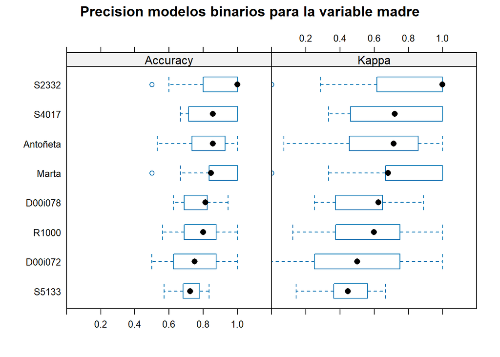

```r
bwplot(modelos.resamplem, main="Precision modelos binarios para la variable madre",  xlim = c(0, 1.2))
```

```r
difestm <- diff(modelos.resamplem, adjustment = "none")
summary(difestm)
```

```
##
## Call:
## summary.diff.resamples(object = difestm)
##
## Upper diagonal: estimates of the difference
## Lower diagonal: p-value for H0: difference = 0
##
## Accuracy
##          S5133     R1000      D00i078    Antoñeta   D00i072    S4017
## S5133              -0.0567528 -0.0620691 -0.1001655 -0.0656814 -0.1377052
## R1000    0.0052935            -0.0053163 -0.0434127 -0.0089286 -0.0809524
## D00i078  0.0027936 0.8140225             -0.0380964 -0.0036123 -0.0756361
## Antoñeta 0.0009542 0.1853538  0.1987864              0.0344841 -0.0375397
## D00i072  0.0356888 0.7848446  0.9188537  0.2917525             -0.0720238
## S4017    3.916e-07 0.0019607  0.0043710  0.2369232  0.0458916
## Marta    4.512e-07 0.0017277  0.0093817  0.3096486  0.0801325  0.9942010
## S2332    3.243e-07 0.0004920  0.0004305  0.0342512  0.0056393  0.2981753
##          Marta      S2332
## S5133    -0.1375068 -0.1754433
## R1000    -0.0807540 -0.1186905
## D00i078  -0.0754377 -0.1133742
## Antoñeta -0.0373413 -0.0752778
## D00i072  -0.0718254 -0.1097619
## S4017     0.0001984 -0.0377381
## Marta               -0.0379365
## S2332    0.3119062
##
## Kappa
##          S5133     R1000     D00i078   Antoñeta  D00i072   S4017     Marta
## S5133              -0.113719 -0.123456 -0.200124 -0.132178 -0.269431 -0.274316
## R1000    0.0052914           -0.009737 -0.086405 -0.018460 -0.155712 -0.160597
## D00i078  0.0030968 0.8298107           -0.076668 -0.008722 -0.145975 -0.150860
## Antoñeta 0.0009583 0.1872943 0.1970573            0.067945 -0.069307 -0.074192
## D00i072  0.0339149 0.7775849 0.9019773 0.2948593           -0.137252 -0.142137
## S4017    6.815e-07 0.0032284 0.0070834 0.2811905 0.0542156           -0.004885
## Marta    4.999e-07 0.0018817 0.0095698 0.3129253 0.0835157 0.9288072
## S2332    3.672e-07 0.0004607 0.0004318 0.0324055 0.0050049 0.2681137 0.3148220
##          S2332
## S5133    -0.349991
## R1000    -0.236272
## D00i078  -0.226535
## Antoñeta -0.149867
## D00i072  -0.217812
## S4017    -0.080560
## Marta    -0.075675
## S2332
```

# 5. NUMERO DE VECES QUE APARECE UNA VARIABLE EN EL TOP 5

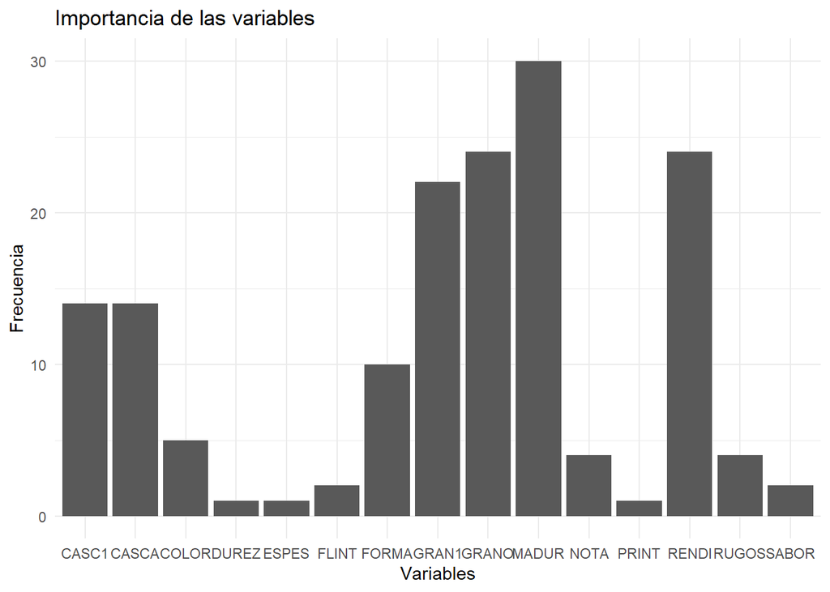

```r
library(ggplot2)
# Datos de ejemplo
nombres_variables <- c("RENDI", "MADUR", "ESPES", "FORMA", "GRAN1", "GRANO", "CASCA", "CASC1", "PRINT", "NOTA", "COLOR", "SABOR", "FLINT", "RUGOS", "DUREZ")
numero_veces <- c(24, 30, 1, 10, 22, 24, 14, 14, 1, 4, 5, 2, 2, 4, 1)

# Crear el dataframe con los datos
datosTOP<- data.frame(Nombres = nombres_variables, Veces = numero_veces)

# Crear el histograma
ggplot(datosTOP, aes(x = Nombres, y = Veces)) +
  geom_bar(stat = "identity") +
  xlab("Variables") +
  ylab("Frecuencia") +
  ggtitle("Importancia de las variables") +
  theme_minimal()
```